# Cross-sectional Regressions

```r
library(tidyverse)
library(tidytext)
library(kableExtra)
library(zoo)
library(lubridate)
library(grid)
library(gridExtra)
library(readxl)
library(stringi)
library(haven)
library(cdlTools)
library(ggeffects)
library(modelsummary)
library(sjPlot)
library(sjmisc)
# Prepares lm objects for plotting
plotify <- function(model){
  retVal <- tidy(model, conf.int = TRUE) %>%
    filter(term != "(Intercept)")
    return(retVal[,1:7])
  }
```

Get tweet counts in cross-sectional form, merge member and constituency factors

```r
library(Hmisc)

tweet.totals.official <- data.text.official.covid.all %>% group_by(name) %>%
  select(-tweet.text, -date.time, -client,
         -retweets, -likes, -date, -document_ID) %>%
  group_by(name) %>%
  mutate(total.covid.tweets= sum(covid_flag),
         total.tweets=n()) %>%
  select(-covid_flag) %>%
  unique() %>%
  mutate(tweet.share.covid = total.covid.tweets/total.tweets) %>%
  mutate(party=recode(party.code, `100`=1, `200`=0)) %>%
  select(-party.code) %>%
  mutate(age=2020-year.born) %>%
  group_by(chamber) %>%
  arrange(chamber, name) %>%
  left_join(
    pan.tweets.flagged.ind %>%
      ungroup() %>%
      group_by(name) %>%
      dplyr::summarize(group5.tweet.all.share = sum(flag_5)/n(),
        group5.tweet.covid.share = sum(flag_5)/sum(covid_flag),
        group6.tweet.all.share = sum(flag_6)/n(),
        group6.tweet.covid.share = sum(flag_6)/sum(covid_flag)),
    by="name")


CEL_Senate <- read_excel("Data/Member_Factors/CELSenate93to116.xlsx") %>% filter(congressnumber==116) %>%
  select(lastname, state.abb, district, year.born, year.elected, gender, african.american, latino, last.vote.share, committee.chair,
         subcommittee.chair, seniority, sponsored.bills, effectiveness.score)

CEL_House <- read_excel("Data/Member_Factors/CELHouse93to116.xlsx") %>% filter(congressnumber==116) %>%
  select(lastname, state.abb, district, year.born, year.elected, gender, african.american, latino, last.vote.share, committee.chair,
         subcommittee.chair, seniority, sponsored.bills, effectiveness.score)

CEL_All <- rbind(CEL_House, CEL_Senate)
rm(CEL_House, CEL_Senate)

tweet.totals.official <- full_join(tweet.totals.official, CEL_All, by=c("state.abb", "district", "year.born")) %>% filter(!is.na(name)) %>% unique()


# CCES2018 <- read_stata("Data/Constituency_Factors/CCES2018/cces18_common_vv.dta") %>%
#   select(inputstate, cdid116, pid7, pid3, ideo5, birthyr,
#          race, urbancity, educ, employ, faminc_new, union) %>%
#   rename(state=inputstate, district=cdid116, family.income=faminc_new) %>%
#   mutate(district=as.numeric(district),
#          state=fips(state, to="Abbreviation"))

CCES2020 <- read_stata("Data/Constituency_Factors/CCES2020/CES20_Common_OUTPUT_vv.dta") %>%
  select(inputstate, cdid116, pid7, pid3, ideo5, birthyr,
         race, urbancity, educ, employ, faminc_new, union) %>%
  rename(state=inputstate, district=cdid116, family.income=faminc_new) %>%
  mutate(district=as.numeric(district),
         state=fips(state, to="Abbreviation"))

# pid3
pid3.df <- CCES2020 %>% select(state, district, pid3) %>% group_by(state, district) %>%
  count(pid3) %>% rename(pid3.count=n) %>% mutate(pid3.total.cd=sum(pid3.count)) %>%
  dplyr::summarize(pid3=pid3, pid3.share = round(pid3.count/pid3.total.cd,3), across()) %>%
  mutate(pid3=recode(as.numeric(pid3), `1`="democrat.cd", `2`="republican.cd",
                     `3`="independent", `4`="other",
                     `5`="unsure")) %>%
  pivot_wider(names_from=pid3,
              values_from=c(pid3.share, pid3.count)) %>%
  select(-contains("_NA"), -contains("unsure"), -contains("other"), -contains("independent"))
tweet.totals.official <- full_join(tweet.totals.official, pid3.df, by=c("state.abb"="state", "district"="district"))
rm(pid3.df)

# pid7
pid7.df <- CCES2020 %>% select(state, district, pid7) %>% group_by(state, district) %>%
  count(pid7) %>% rename(pid7.count=n) %>% mutate(pid7.total.cd=sum(pid7.count)) %>%
  dplyr::summarize(pid7=pid7, pid7.share = round(pid7.count/pid7.total.cd,3), across()) %>%
  mutate(pid7=recode(as.numeric(pid7), `1`="strongdem", `2`="weakdem",
                     `3`="leandem", `4`="independent",
                     `5`="leanrep", `6`="weakrep",
                     `7`="strongrep", `8`="unsure")) %>%
  pivot_wider(names_from=pid7,
              values_from=c(pid7.share, pid7.count)) %>%
  mutate(pid7.share_democrat.cd=pid7.share_strongdem + pid7.share_weakdem + pid7.share_leandem,
         pid7.share_republican.cd=pid7.share_strongrep + pid7.share_weakrep + pid7.share_leanrep,
         pid7.count_democrat.cd=pid7.count_strongdem + pid7.count_weakdem + pid7.count_leandem,
         pid7.count_republican.cd=pid7.count_strongrep + pid7.count_weakrep + pid7.count_leanrep
         ) %>%
  select(state, district, pid7.share_democrat.cd, pid7.share_republican.cd, pid7.total.cd,
         pid7.count_democrat.cd, pid7.count_republican.cd)
tweet.totals.official <- full_join(tweet.totals.official, pid7.df, by=c("state.abb"="state", "district"="district"))
rm(pid7.df)

#ideo5 cd
ideo5.df <- CCES2020 %>% select(state, district, ideo5) %>% group_by(state, district) %>%
  mutate(ideo5=recode(as.numeric(ideo5), `1`=-2, `2`=-1,
                     `3`=0, `4`=1, `5`=2, `6`=NA_real_)) %>%
  dplyr::summarize(ideo5.cd = round(mean(ideo5, na.rm=T),3))
tweet.totals.official <- full_join(tweet.totals.official, ideo5.df, by=c("state.abb"="state", "district"="district"))
rm(ideo5.df)

#ideo5 state
ideo5.df <- CCES2020 %>% select(state, ideo5) %>% group_by(state) %>%
  mutate(ideo5=recode(as.numeric(ideo5), `1`=-2, `2`=-1,
                     `3`=0, `4`=1, `5`=2, `6`=NA_real_)) %>%
  dplyr::summarize(ideo5.state = round(mean(ideo5, na.rm=T),3))

tweet.totals.official <- full_join(tweet.totals.official, ideo5.df, by=c("state.abb"="state"))
rm(ideo5.df)

# birthyr cd
birthyr.df <- CCES2020 %>% select(state, district, birthyr) %>% group_by(state, district) %>%
  mutate(age = 2020-birthyr) %>%
  dplyr::summarize(mean.age.cd = round(mean(age, na.rm=T),1),
            median.age.cd = median(age, na.rm=T))
tweet.totals.official <- full_join(tweet.totals.official, birthyr.df, by=c("state.abb"="state", "district"="district"))
rm(birthyr.df)

# birthyr state
birthyr.df <- CCES2020 %>% select(state, birthyr) %>% group_by(state) %>%
  mutate(age = 2020-birthyr) %>%
  dplyr::summarize(mean.age.state = round(mean(age, na.rm=T),1),
            median.age.state = median(age, na.rm=T))

tweet.totals.official <- full_join(tweet.totals.official, birthyr.df, by=c("state.abb"="state"))
rm(birthyr.df)
```

```r
# race
race.df <- CCES2020 %>% select(state, district, race) %>% group_by(state, district) %>%
  count(race) %>% rename(race.count=n) %>% mutate(race.total.cd=sum(race.count)) %>%
  dplyr::summarize(race=race, race.share = round(race.count/race.total.cd,3), across()) %>%
  mutate(race=recode(as.numeric(race), `1`="white.cd", `2`="black.cd",
                     `3`="hispanic.cd", `4`="asian.cd", `5`="native.cd",
                     `6`="mixed.cd", `7`="other.cd", `8`="middleeast.cd")) %>%
  pivot_wider(names_from=race,
              values_from=c(race.share, race.count)) %>%
  select(state,district, contains("white"), contains("black"), contains("hispanic"), race.total.cd)
tweet.totals.official <- full_join(tweet.totals.official, race.df, by=c("state.abb"="state", "district"="district"))
rm(race.df)

# Calculate state level for pid3, pid7, race

tweet.totals.official <- tweet.totals.official %>% group_by(state.abb) %>%
  mutate(pid3.share_democrat.state=round(sum(pid3.count_democrat.cd, na.rm=T)/sum(pid3.total.cd, na.rm=T),3),
         pid3.share_republican.state=round(sum(pid3.count_republican.cd, na.rm=T)/sum(pid3.total.cd, na.rm=T),3),
         pid7.share_democrat.state=round(sum(pid7.count_democrat.cd, na.rm=T)/sum(pid7.total.cd, na.rm=T),3),
         pid7.share_republican.state=round(sum(pid7.count_republican.cd, na.rm=T)/sum(pid7.total.cd, na.rm=T),3),
         race.share_white.state=round(sum(race.count_white.cd, na.rm=T)/sum(race.total.cd, na.rm=T),3),
         race.share_black.state=round(sum(race.count_black.cd, na.rm=T)/sum(race.total.cd, na.rm=T),3),
         race.share_hispanic.state=round(sum(race.count_hispanic.cd, na.rm=T)/sum(race.total.cd, na.rm=T),3)) %>%
  select(-contains(".count"), -contains(".total."))

# Get 2010 Census data for employment info
Census2010 <- read.csv("Data/Constituency_Factors/Census2010.csv") %>%
  filter(CongDist!="", CongDist!="ZZ")

# Complete label row
Census2010[1,1] <- "State"

# Assign labels
label(Census2010) <- Census2010[1,]

# Remove label row
Census2010 <- Census2010[2:nrow(Census2010),]

# Reformat dollars in characters to numeric
Census2010[,3] <- parse_number(Census2010[,3])
Census2010[,4] <- parse_number(Census2010[,4])
Census2010[,5] <- parse_number(Census2010[,5])

Census2010$state.abb <- fips(Census2010$State, to="Abbreviation")

Census2010[,1:62] <- Census2010[,1:62] %>% mutate_if(is.character, parse_number)

# Aggregated by state
Census2010.state <- Census2010 %>% select(-contains("pct")) %>% group_by(state.abb) %>%
  mutate(statePop = sum(TotPop)) %>%
  dplyr::summarize(pctLaborForce.state = round(sum(LaborForce)/statePop,3),
             pctCivLabForce.state = round(sum(CivLabForce)/statePop,3),
             pctManufacturing.state = round(sum(Manufacturing)/statePop,3),
             pctRetailTrade.state = round(sum(RetailTrade)/statePop,3),
             pctEduc_Health_SocSvcs.state = round(sum(Educ_Health_SocSvcs)/statePop,3),
             pctConstruction.state = round(sum(Construction)/statePop,3),
             pctGovWorkers.state = round(sum(GovWorkers)/statePop,3),
             pctSelfEmpWorkers.state = round(sum(SelfEmpWorkers)/statePop,3),
             by=state.abb) %>% unique()
# Aggregated by cd
Census2010.cd <- Census2010 %>% select(state.abb, CongDist, pctLaborForce,
                      pctCivLabForce, pctManufacturing, pctRetailTrade,
                      pctEduc_Health_SocSvcs, pctConstruction, pctGovWorkers,
                      pctSelfEmpWorkers) %>%
  transmute(pctLaborForce.cd = pctLaborForce/100,
    pctCivLabForce.cd = pctCivLabForce/100,
    pctManufacturing.cd = pctManufacturing/100,
    pctRetailTrade.cd = pctRetailTrade/100,
    pctEduc_Health_SocSvcs.cd = pctEduc_Health_SocSvcs/100,
    pctConstruction.cd = pctConstruction/100,
    pctGovWorkers.cd = pctGovWorkers/100,
    pctSelfEmpWorkers.cd = pctSelfEmpWorkers/100,
    district=recode(CongDist, `0`=1),
    state.abb=state.abb)

# Merge state data
tweet.totals.official <- left_join(tweet.totals.official, Census2010.state, by="state.abb") %>% select(-by)

# Merge CD data
tweet.totals.official <- left_join(tweet.totals.official, Census2010.cd, by=c("state.abb","district"))


# Census 2010 Urbanicity Data
Census2010UrbanRural <- read_excel("Data/Constituency_Factors/Census2010UrbanRural.xlsx",
           sheet="Data") %>%
  drop_na() %>%
  mutate(
    pctRural.cd=round(PctRural.cd,3),
    pctUrban.cd=round(PctUrban.cd,3)) %>%
  select(-PctRural.cd, -PctUrban.cd) %>%
  rename(district=District)

Census2010UrbanRural[,3:5] <- Census2010UrbanRural[,3:5] %>% mutate_if(is.character, parse_number)

Census2010UrbanRural$state.abb <- state.abb[match(Census2010UrbanRural$State,state.name)]


Census2010UrbanRural.state <- Census2010UrbanRural %>% group_by(state.abb) %>%
  dplyr::summarize(
    pctRural.state = round(sum(TotalRural)/sum(TotalHouseholds),3),
    pctUrban.state = round(sum(TotalUrban)/sum(TotalHouseholds),3),
  )


Census2010UrbanRural.cd <- Census2010UrbanRural %>%
  select(-State, -TotalHouseholds, -TotalRural, -TotalUrban)

# Merge state data
tweet.totals.official <- left_join(tweet.totals.official, Census2010UrbanRural.state, by="state.abb")

# Merge CD data
tweet.totals.official <- left_join(tweet.totals.official, Census2010UrbanRural.cd, by=c("state.abb","district"))

# Get baseline tweet counts
tweet.totals.official.baseline <- data.text.official.prepandemic.all %>% filter(date >= "2019-01-19" & date <= "2019-11-28") %>%
  group_by(state.abb, district) %>%
  dplyr::summarize(total.tweet.baseline=n())
tweet.totals.official <- left_join(tweet.totals.official, tweet.totals.official.baseline, by=c("district", "state.abb"))

# impute NYC COVID data
missing_cds <- c(6,7,8,9,10,11,12,13,14,15)

covid.NYC <- read.csv("Data/COVID_Indicator_Dataframes/covid_NYC.csv") %>%
  select(date_of_interest, CASE_COUNT, DEATH_COUNT) %>%
  rename(cd_incremental_cases = CASE_COUNT,
         cd_incremental_deaths = DEATH_COUNT,
         date=date_of_interest) %>%
  # mutate(cd_incremental_cases =  cd_incremental_cases/length(missing_cds),       # divide evenly
  #        cd_incremental_deaths = cd_incremental_deaths/length(missing_cds)) %>%  # amongst NYC reps
  mutate(cd_incremental_cases =  cd_incremental_cases/length(missing_cds),       # assign each NYC member
         cd_incremental_deaths = cd_incremental_deaths/length(missing_cds)) %>%  # share of citywide indicators
  mutate(date=as.Date(date, "%m/%d/%Y")) %>%
  arrange(date) %>%
  mutate(cd_cum_deaths = ave(cd_incremental_deaths, FUN=cumsum),
         cd_cum_cases = ave(cd_incremental_cases, FUN=cumsum))  %>%
  filter(date >= "2020-01-19" & date <= "2020-11-28")
```

```r
dist_col <- sort(rep(missing_cds, nrow(covid.NYC)))

covid.NYC <- bind_rows(replicate(length(missing_cds), covid.NYC, simplify=F)) %>%
  mutate(state.abb="NY", district=dist_col)



# [UNFINISHED] More accurate method to get CD-level indicators

# NYC.crosswalk <- read.csv("Data/COVID_Indicator_Dataframes/NYCcrosswalk.csv") %>%
#   full_join(read.csv("Data/COVID_Indicator_Dataframes/NY_block_population_census2010.csv"),
#             by=c("block", "tract")) %>%
#   mutate(block.population = as.numeric(
#     str_remove(block.population, "\\(r[:digit:]{5}\\)"))) %>%  # remove coding
#     filter(district %in% missing_cds)
#
# NYC.crosswalk %>% group_by(district) %>% summarize(district.population = sum(block.population, na.rm=T), across()) %>% View()
#
# # POP TOTALS NOT RIGHT
# (NYC.crosswalk %>% group_by(district, boro) %>% summarize(cd.boro.population = sum(block.population, na.rm=T), across())) %>% select(district, boro, cd.boro.population) %>%
#   unique() %>% group_by(district) %>%
#   summarize(cd.population = sum(cd.boro.population, na.rm=T), across()) %>%
#   mutate(share.pop.boro.cd = round(cd.boro.population/cd.population,3)) %>% View()
#
#
# covid.NYC <- read.csv("Data/COVID_Indicator_Dataframes/covid_NYC.csv")


covid.CD <- read.csv("Data/COVID_Indicator_Dataframes/covid_cd.csv") %>%
  mutate(date=as.Date(date, "%Y-%m-%d")) %>%
  select(-StateName, -StateCode) %>%
  group_by(state.abb, district) %>% arrange(date, .by_group=T) %>%
  dplyr::mutate(cd_cum_cases = ave(cd_incremental_cases, state.abb, district, FUN=cumsum),
                cd_cum_deaths = ave(cd_incremental_deaths, state.abb, district, FUN=cumsum)) %>%
  filter(date >= "2020-01-19" & date <= "2020-11-28")

covid.CD <- bind_rows(covid.CD, covid.NYC) %>% unique()


covid.state <- read.csv("Data/COVID_Indicator_Dataframes/covid_state.csv") %>%
  mutate(date=as.Date(date, "%Y-%m-%d")) %>%
  group_by(state.abb) %>% arrange(date, .by_group=T) %>%
  dplyr::mutate(state_cum_cases = ave(state_incremental_cases, state.abb, FUN=cumsum),
                state_cum_deaths = ave(state_incremental_deaths, state.abb, FUN=cumsum)) %>%
  filter(date >= "2020-01-19" & date <= "2020-11-28") %>%
  group_by(state.abb) %>% arrange(date, .by_group=T)


covid.national <- read.csv("Data/COVID_Indicator_Dataframes/covid_national.csv") %>%
  mutate(date=as.Date(date, "%Y-%m-%d")) %>%
  arrange(date) %>%
  dplyr::mutate(national_cum_cases = ave(national_incremental_cases, FUN=cumsum),
                national_cum_deaths = ave(national_incremental_deaths, FUN=cumsum)) %>%
  filter(date >= "2020-01-19" & date <= "2020-11-28")


# Get total COVID deaths at CD, state, nat'l level

totals.cd <- covid.CD %>% filter(date == "2020-11-28") %>%
  select(cd_cum_deaths, cd_cum_cases, state.abb, district)

totals.state <- covid.state %>% filter(date == "2020-11-28") %>%
  select(state_cum_deaths, state_cum_cases, state.abb)

totals.natl <- covid.national %>% filter(date == "2020-11-28") %>%
  select(national_cum_deaths, national_cum_cases)

tweet.totals.official <- left_join(tweet.totals.official,
                                   totals.cd,
                                   by=c("state.abb", "district"))

tweet.totals.official <- left_join(tweet.totals.official, totals.state, by=c("state.abb"))

tweet.totals.official$natl.deaths =  totals.natl$national_cum_deaths

tweet.totals.official$natl.cases =  totals.natl$national_cum_cases


tweet.totals.official <- tweet.totals.official %>%
  rename(cd.deaths=cd_cum_deaths, cd.cases=cd_cum_cases,
         state.deaths=state_cum_deaths, state.cases=state_cum_cases) %>%
  unique()


# Add age-squared variables
tweet.totals.official$age.squared <- (tweet.totals.official$age)^2
tweet.totals.official$median.age.squared.cd <- (tweet.totals.official$median.age.cd)^2
tweet.totals.official$median.age.squared.state <- (tweet.totals.official$median.age.state)^2

# Setting Justin Amash party to 0
tweet.totals.official$party[tweet.totals.official$name=="Justin Amash"] = 0

# Creating AA or Latino dummy
tweet.totals.official <- tweet.totals.official %>% mutate(aa.or.lat = case_when(
  african.american==1 | latino==1 ~ 1,
  TRUE ~ 0
))

temp <- read_excel("Data/Constituency_Factors/ballotpedia_governor_parties.xlsx") %>%
  mutate(state.abb=state.abb[which(state.name==state)]) %>% select(-state)

tweet.totals.official <- tweet.totals.official %>% left_join(temp)
rm(temp)

# Convert state and cd deaths to hundreds of deaths for easier reading of regression coefficients
# tweet.totals.official$cd.deaths <- tweet.totals.official$cd.deaths/100
# tweet.totals.official$state.deaths <- tweet.totals.official$state.deaths/100
```

# Other

Visualize distribution of tweet totals

[output not shown]

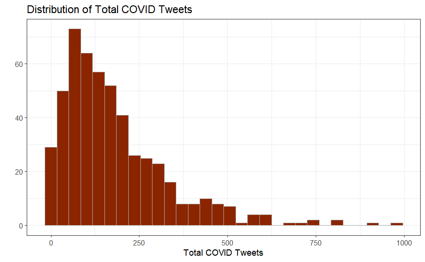

```r
ggplot(data=tweet.totals.official, aes(x=total.covid.tweets)) +
  geom_histogram(fill="orangered4", color="darkgray") +
  labs(x="Total COVID Tweets",y="", title="Distribution of Total COVID Tweets") +
  theme_bw()
```

```
Warning: Removed 18 rows containing non-finite values (stat_bin).
```

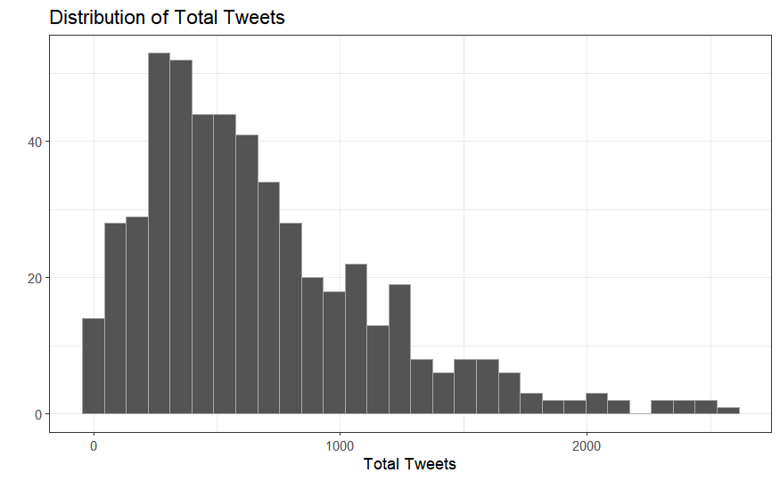

```r
ggplot(data=tweet.totals.official, aes(x=total.tweets)) +
  geom_histogram(fill="grey33", color="darkgray") +
  labs(x="Total Tweets",y="", title="Distribution of Total Tweets") +
  theme_bw()
```

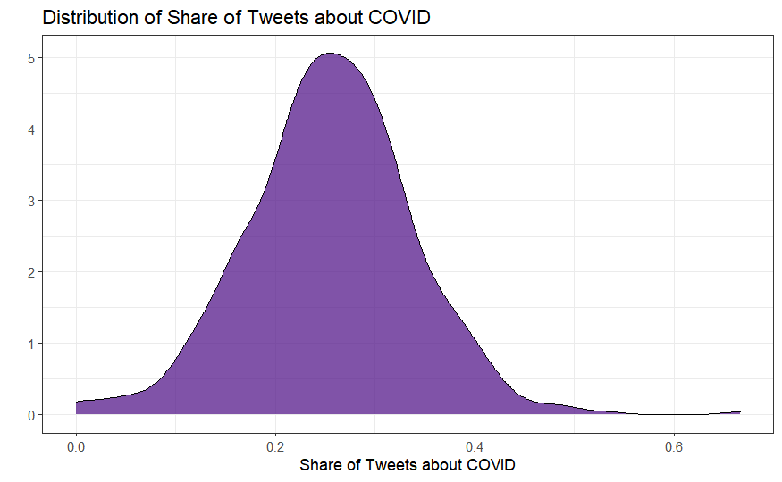

```r
ggplot(data=tweet.totals.official, aes(x=tweet.share.covid)) +
  geom_density(fill="purple4", color="black", alpha=0.75) +
  labs(x="Share of Tweets about COVID",y="", title="Distribution of Share of Tweets about COVID") +
  theme_bw()
```

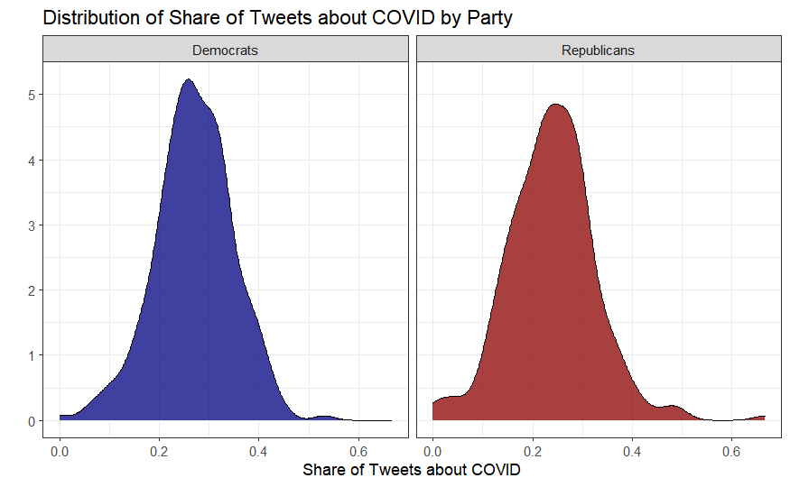

```r
party_names <- list("100"="Democrats", "200"="Republicans")

label_it <- function(variable,value){
  return(party_names[value])
}

ggplot(data=tweet.totals.official %>% filter(party %in% 0:1) %>%
         mutate(party=recode(party, `1`="Democrats", `0`="Republicans")),
       aes(x=tweet.share.covid, fill=as.factor(party))) +
  geom_density(color="black", alpha=0.75) +
  labs(x="Share of Tweets about COVID",y="", title="Distribution of Share of Tweets about COVID by Party") +
  theme_bw() +
  facet_wrap(~party) +
  scale_fill_manual(values=c("Democrats"="navyblue", "Republicans"="darkred")) +
  theme(legend.position="none")
```

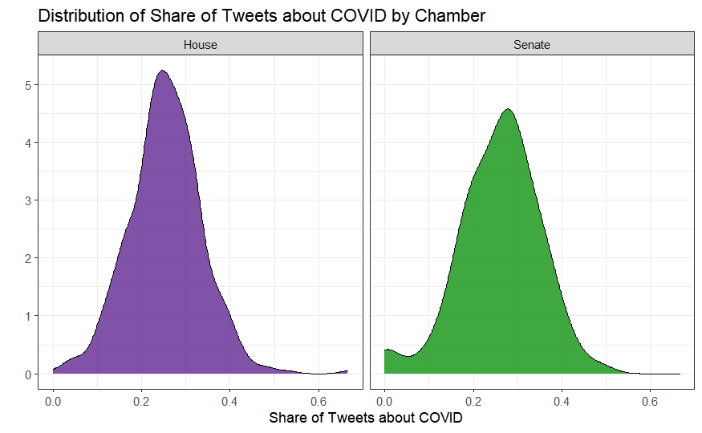

```r
ggplot(data=tweet.totals.official %>% drop_na(chamber),
       aes(x=tweet.share.covid, fill=as.factor(chamber))) +
  geom_density(color="black", alpha=0.75) +
  labs(x="Share of Tweets about COVID",y="", title="Distribution of Share of Tweets about COVID by Chamber") +
  theme_bw() +
  facet_wrap(~chamber) +
  scale_fill_manual(values=c("House"="purple4", "Senate"="green4")) +
  theme(legend.position="none")
```

Visualize distribution of COVID deaths

```
Warning: Removed 96 rows containing non-finite values (stat_bin).
```

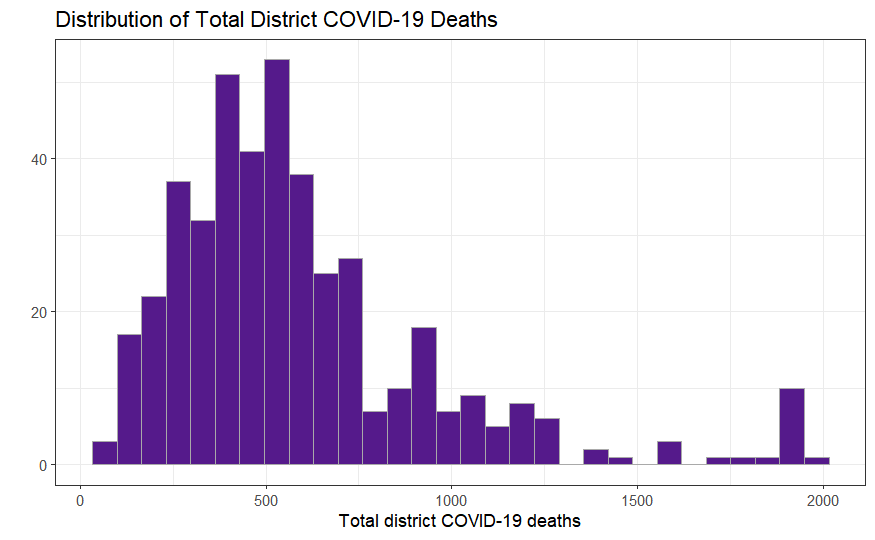

```r
ggplot(data=tweet.totals.official, aes(x=cd.deaths)) +
  geom_histogram(fill="purple4", color="darkgray") +
  labs(x="Total district COVID-19 deaths",y="", title="Distribution of Total District COVID-19 Deaths") +
  theme_bw()
```

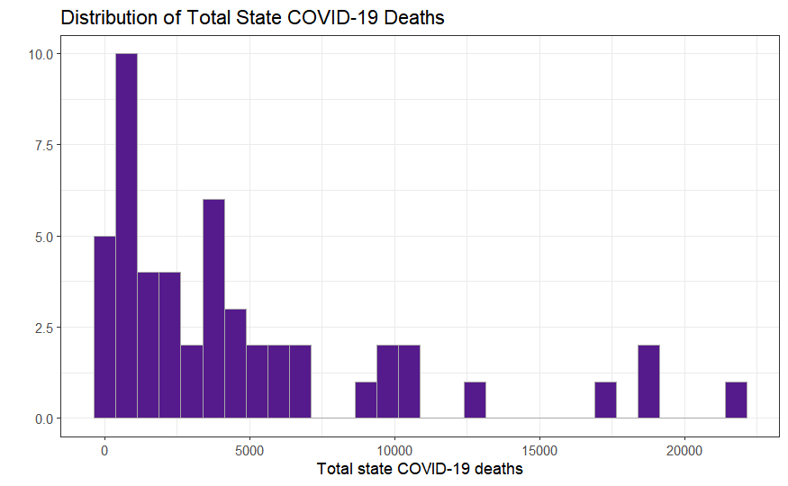

```r
ggplot(data=tweet.totals.official %>% select(state.abb, state.deaths) %>% filter(state.abb!="DC") %>% unique(), aes(x=state.deaths)) +
  geom_histogram(fill="purple4", color="darkgray") +
  labs(x="Total state COVID-19 deaths",y="", title="Distribution of Total State COVID-19 Deaths") +
  theme_bw()
```

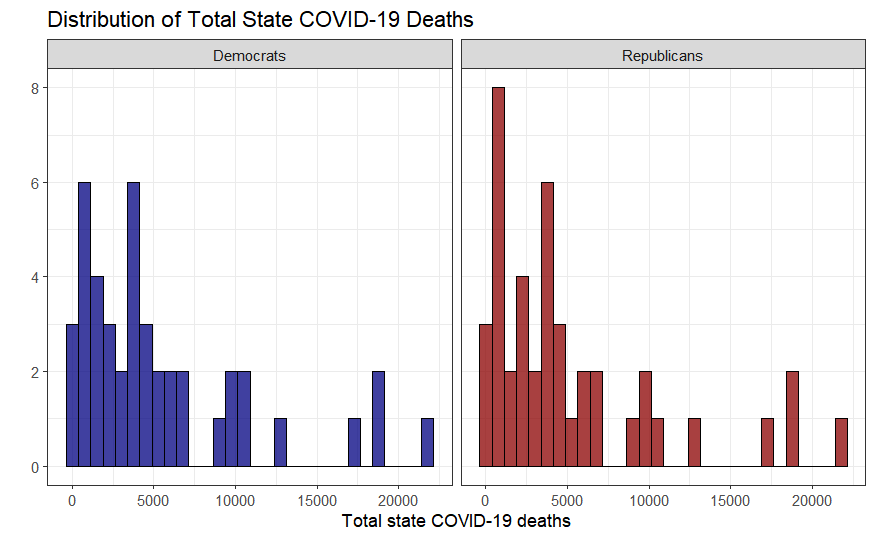

```r
ggplot(data=tweet.totals.official %>% select(state.abb, state.deaths, party) %>%
         filter(state.abb!="DC") %>% unique() %>% drop_na() %>%
         mutate(party=recode(party, `1`="Democrats", `0`="Republicans")),
       aes(x=state.deaths, fill=as.factor(party))) +
  geom_histogram(color="black", alpha=0.75) +
  labs(x="Total state COVID-19 deaths",y="", title="Distribution of Total State COVID-19 Deaths") +
  theme_bw() +
  facet_wrap(~party) +
  scale_fill_manual(values=c("Democrats"="navyblue", "Republicans"="darkred")) +
  theme(legend.position="none")
```

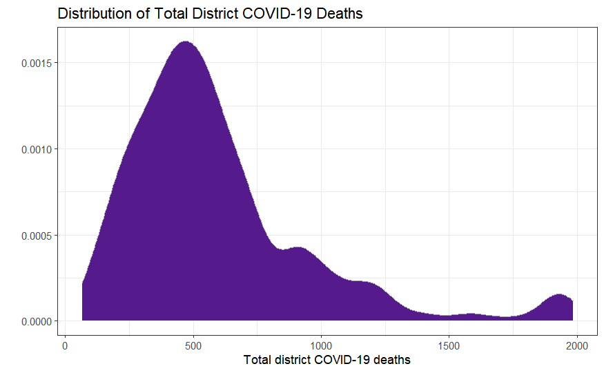

```r
party_names <- list("100"="Democrats", "200"="Republicans")

label_it <- function(variable,value){
  return(party_names[value])
}


ggplot(data=tweet.totals.official, aes(x=cd.deaths)) +
  geom_density(fill="purple4", color="darkgray") +
  labs(x="Total district COVID-19 deaths",y="", title="Distribution of Total District COVID-19 Deaths") +
  theme_bw()
```

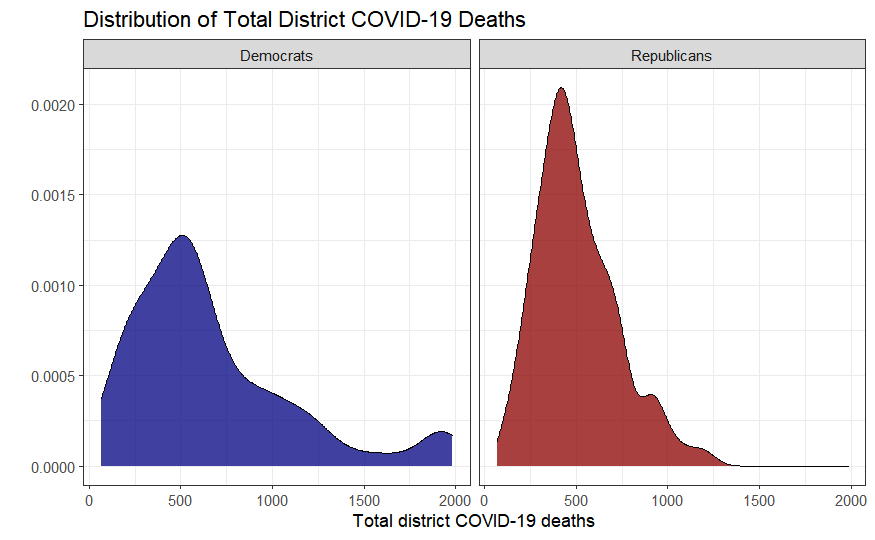

```r
ggplot(data=tweet.totals.official %>% filter(party %in% 0:1) %>%
         mutate(party=recode(party, `1`="Democrats", `0`="Republicans")),
       aes(x=cd.deaths, fill=as.factor(party))) +
  geom_density(color="black", alpha=0.75) +
  labs(x="Total district COVID-19 deaths",y="", title="Distribution of Total District COVID-19 Deaths") +
  theme_bw() +
  facet_wrap(~party) +
  scale_fill_manual(values=c("Democrats"="navyblue", "Republicans"="darkred")) +
  theme(legend.position="none")
```

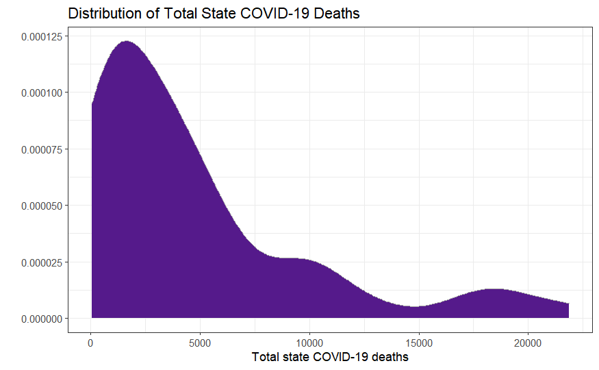

```r
ggplot(data=tweet.totals.official %>% select(state.abb, state.deaths) %>% filter(state.abb!="DC") %>% unique(), aes(x=state.deaths)) +
  geom_density(fill="purple4", color="darkgray") +
  labs(x="Total state COVID-19 deaths",y="", title="Distribution of Total State COVID-19 Deaths") +
  theme_bw()
```

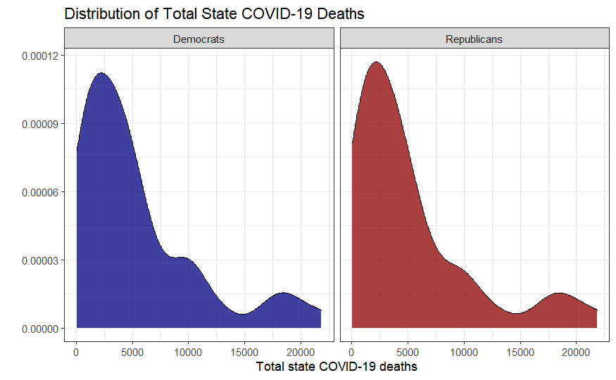

```r
ggplot(data=tweet.totals.official %>% select(state.abb, state.deaths, party) %>%
         filter(state.abb!="DC") %>% unique() %>% drop_na() %>%
         mutate(party=recode(party, `1`="Democrats", `0`="Republicans")),
       aes(x=state.deaths, fill=as.factor(party))) +
  geom_density(color="black", alpha=0.75) +
  labs(x="Total state COVID-19 deaths",y="", title="Distribution of Total State COVID-19 Deaths") +
  theme_bw() +
  facet_wrap(~party) +
  scale_fill_manual(values=c("Democrats"="navyblue", "Republicans"="darkred")) +
  theme(legend.position="none")
```

Diagnostics

INTERACTION PLOTS

```r
qplot(x = party, y = tweet.share.covid,
      data = tweet.totals.official %>% filter(chamber=="House") %>% drop_na(latino),
      color = as.factor(latino)) +
  geom_smooth(method = "lm") +
  xlim(c(-0.125,1.125)) +
  theme_bw()

plot_model(h3h4_lm_House, type = "pred", terms = c("african.american", "party")) +
  xlim(c(-0.1,1.1)) +
  ylim(c(0,1)) +
  theme_bw()
```

SPEC CURVES

Specification curve analysis code

```r
# CODE ADAPTED FROM GARETH NELLIS

# all unique control combinations (i.e. powerset, including the empty set)
# adapted from https://stackoverflow.com/questions/49570793/r-list-all-combinations-with-combn-multiple-m-values
# control_list <-
#   data.frame(
#     x = "sons",
#     controls =
#       list(do.call("c", lapply(seq_along(controls), function(i) utils::combn(controls, i, FUN = list))) %>%
#       map(function(x) paste(x, collapse = " + ")), "") %>%
#       unlist())



# estimation function
spec_curve_ests <-
  function(
    x = NULL,
    controls = NULL) {

  if(controls == "") {plus <- ""} else {plus <- "+"}

      frm <-
        as.formula(paste0("tweet.share.covid ~", x, plus, controls))

      out <-
        #feols(frm, cluster = ~svy_sh_tsp_code, data = analysis_df) %>%
        lm(frm, data=tweet.totals.official) %>%
        tidy(conf.int = T) %>%
        mutate(control_set = as.character(controls))

    }

run_models <- function(IV=NULL, controls=NULL){
  # all unique control combinations (i.e. powerset, including the empty set)
  # adapted from:
  # https://stackoverflow.com/questions/49570793/r-list-all-combinations-with-combn-multiple-m-values
  control_list <- data.frame(
    x = IV,
    controls = list(
      do.call("c", lapply(seq_along(controls),
                          function(i) utils::combn(controls,
                                                   i, FUN = list))) %>%
      map(function(x) paste(x, collapse = " + ")), "") %>%
      unlist())

  res <- pmap_dfr(control_list, .f = spec_curve_ests) %>%
    filter(term == IV) %>%
    arrange(estimate) %>%
    mutate(specifications = 1:nrow(.))

  return(res)
}
```

House model no interactions, cd.deaths as IV

```r
# declare controls
# h3h4_lm_House_controls_prim <-
#   c("age", "latino", "african.american", "last.vote.share", "pctUrban.cd",
#     "median.age.cd", "pctEduc_Health_SocSvcs.cd", "race.share_hispanic.cd",
#     "race.share_black.cd", "party:age", "party:latino", "party:african.american",
#     "cd.deaths:last.vote.share", "cd.deaths:pctUrban.cd", "cd.deaths:median.age.cd",
#     "cd.deaths:pctEduc_Health_SocSvcs.cd", "cd.deaths:race.share_hispanic.cd",
#     "cd.deaths:race.share_black.cd", "pctUrban.cd:race.share_hispanic.cd",
#     "pctUrban.cd:race.share_black.cd")
h3h4_lm_House_controls <-
  c("party", "age", "latino", "african.american", "last.vote.share", "pctUrban.cd",
    "median.age.cd", "pctEduc_Health_SocSvcs.cd", "race.share_hispanic.cd",
    "race.share_black.cd", "pctUrban.cd", "median.age.cd")

h3h4_House_spec <- run_models(IV="cd.deaths", controls=h3h4_lm_House_controls)

# plot top panel
sc1 <-
  h3h4_House_spec %>%
  ggplot(aes(x = specifications, y = estimate)) +
    #geom_pointrange(size=0.25) +
    geom_point(size=0.1) +
    geom_ribbon(aes(ymin = conf.low, ymax = conf.high), fill="red", col="red", alpha=0.15) +
    labs(x = "", y = "Estimate") +
    geom_hline(yintercept = 0, color = "darkblue") +
    ggtitle("") +
    theme_bw()

# lower plot
sc2 <-
  expand.grid(control = h3h4_lm_House_controls,
              specifications = c(1:max(h3h4_House_spec$specifications))) %>%
  left_join(h3h4_House_spec, by = "specifications") %>%
  mutate(value = ifelse(str_detect(control_set, as.character(control)), "|", "")) %>%
  ggplot(aes(specifications, control)) +
    geom_text(aes(label = value)) +
    scale_color_manual(values = c("lightblue")) +
    labs(x = "Specification number", y = "") +
    theme_bw() +
    theme(
      axis.text.y=element_text(size=5.5)
    )

grid.arrange(sc1, sc2)
```

House model salient interactions, cd.deaths as IV

```r
# declare controls
# h3h4_lm_House_controls_prim <-
#   c("age", "latino", "african.american", "last.vote.share", "pctUrban.cd",
#     "median.age.cd", "pctEduc_Health_SocSvcs.cd", "race.share_hispanic.cd",
#     "race.share_black.cd", "party:age", "party:latino", "party:african.american",
#     "cd.deaths:last.vote.share", "cd.deaths:pctUrban.cd", "cd.deaths:median.age.cd",
#     "cd.deaths:pctEduc_Health_SocSvcs.cd", "cd.deaths:race.share_hispanic.cd",
#     "cd.deaths:race.share_black.cd", "pctUrban.cd:race.share_hispanic.cd",
#     "pctUrban.cd:race.share_black.cd")
h3h4_lm_House_controls2 <-
  c("state.deaths","party", "age", "age.squared", "latino", "african.american", "last.vote.share", "pctUrban.cd",
    "median.age.cd", "median.age.squared.cd", "pctEduc_Health_SocSvcs.cd", "race.share_hispanic.cd",
    "race.share_black.cd", "pctUrban.cd", "party:age",
    "cd.deaths:pctUrban.cd")

h3h4_House_spec <- run_models(IV="cd.deaths", controls=h3h4_lm_House_controls2)

# plot top panel
sc3 <-
  h3h4_House_spec %>%
  ggplot(aes(x = specifications, y = estimate)) +
    #geom_pointrange(size=0.25) +
    geom_point(size=0.1) +
    geom_ribbon(aes(ymin = conf.low, ymax = conf.high), fill="red", col="red", alpha=0.15) +
    labs(x = "", y = "District Deaths Coefficient Estimate",
         title="District Deaths Specification Curve Analysis") +
    geom_hline(yintercept = 0, color = "darkblue") +
    theme_bw() +
    theme(
      axis.title.y = element_text(size=7),
      axis.text.y=element_text(size=7),
      title = element_text(size=8)
    )

# lower plot
sc4 <-
  expand.grid(control = h3h4_lm_House_controls2,
              specifications = c(1:max(h3h4_House_spec$specifications))) %>%
  left_join(h3h4_House_spec, by = "specifications") %>%
  mutate(value = ifelse(str_detect(control_set, as.character(control)), "|", "")) %>%
  ggplot(aes(specifications, control)) +
    geom_text(aes(label = value), size=0.75) +
    scale_color_manual(values = c("lightblue")) +
    labs(x = "Specification number", y = "") +
    scale_y_discrete(labels=rev(c("District deaths*Share urban",
                              "Is Democrat*Member age",
                              "Share AA",
                              "Share Hispanic",
                              "Share in E,H,SS",
                              "Median age",
                              "Share urban",
                              "Vote share won",
                              "Is AA",
                              "Is Latino",
                              "Member age",
                              "Is Democrat",
                              "State deaths"))) +
    theme_bw() +
    theme(
        axis.text.y=element_text(size=5.5)
      )

#grid.arrange(sc3, sc4)

grid::grid.newpage()
grid::grid.draw(rbind(ggplotGrob(sc3), ggplotGrob(sc4)))
```

House model table interactions, cd.deaths as IV TOO MANY MODELS TO RUN

```r
c("cd.deaths",
"state.deaths",
"party",
"age",
"african.american",
"latino",
"cd.deaths:party",
"party:age",
"party:latino",
"party:african.american",
"last.vote.share",
"pctUrban.cd",
"median.age.cd",
"pctEduc_Health_SocSvcs.cd",
"race.share_black.cd",
"race.share_hispanic.cd",
"cd.deaths:last.vote.share",
"cd.deaths:median.age.cd",
"cd.deaths:pctEduc_Health_SocSvcs.cd",
"cd.deaths:pctUrban.cd",
"cd.deaths:race.share_hispanic.cd",
"cd.deaths:race.share_black.cd",
"pctUrban.cd:race.share_hispanic.cd",
"pctUrban.cd:race.share_black.cd")
```

House model salient interactions, party as IV

```r
# declare controls
# h3h4_lm_House_controls_prim <-
#   c("age", "latino", "african.american", "last.vote.share", "pctUrban.cd",
#     "median.age.cd", "pctEduc_Health_SocSvcs.cd", "race.share_hispanic.cd",
#     "race.share_black.cd", "party:age", "party:latino", "party:african.american",
#     "cd.deaths:last.vote.share", "cd.deaths:pctUrban.cd", "cd.deaths:median.age.cd",
#     "cd.deaths:pctEduc_Health_SocSvcs.cd", "cd.deaths:race.share_hispanic.cd",
#     "cd.deaths:race.share_black.cd", "pctUrban.cd:race.share_hispanic.cd",
#     "pctUrban.cd:race.share_black.cd")
h3h4_lm_House_controls3 <-
  c("cd.deaths", "state.deaths", "age", "age.squared","latino", "african.american", "last.vote.share", "pctUrban.cd",
    "median.age.cd", "pctEduc_Health_SocSvcs.cd", "race.share_hispanic.cd",
    "race.share_black.cd", "pctUrban.cd", "median.age.cd", "party:age", "party:age.squared",
    "cd.deaths:pctUrban.cd")

h3h4_House_spec <- run_models(IV="party", controls=h3h4_lm_House_controls3)

# plot top panel
sc5 <-
  h3h4_House_spec %>%
  ggplot(aes(x = specifications, y = estimate)) +
    #geom_pointrange(size=0.25) +
    geom_point(size=0.1) +
    geom_ribbon(aes(ymin = conf.low, ymax = conf.high), fill="red", col="red", alpha=0.15) +
    labs(x = "", y = "Party Coefficient Estimate",
         title="Party Specification Curve Analysis") +
    geom_hline(yintercept = 0, color = "darkblue") +
    theme_bw() +
    theme(
      axis.title.y = element_text(size=7),
      axis.text.y=element_text(size=7),
      title = element_text(size=8)
    )

# lower plot
sc6 <-
  expand.grid(control = h3h4_lm_House_controls3,
              specifications = c(1:max(h3h4_House_spec$specifications))) %>%
  left_join(h3h4_House_spec, by = "specifications") %>%
  mutate(value = ifelse(str_detect(control_set, as.character(control)), "|", "")) %>%
  ggplot(aes(specifications, control)) +
    geom_text(aes(label = value), size=0.75) +
    scale_color_manual(values = c("lightblue")) +
    labs(x = "Specification number", y = "") +
    scale_y_discrete(labels=rev(c("District deaths*Share urban",
                                  "Is Democrat*Member age sq.",
                                  "Is Democrat*Member age",
                                  "Share AA",
                                  "Share Hispanic",
                                  "Share in E,H,SS",
                                  "Median age",
                                  "Share urban",
                                  "Vote share won",
                                  "Is AA",
                                  "Is Latino",
                                  "Member age squ.",
                                  "Member age",
                                  "State deaths",
                                  "District deaths"))) +
    theme_bw() +
  theme(
      axis.text.y=element_text(size=5.5)
    )

grid::grid.newpage()
grid::grid.draw(rbind(ggplotGrob(sc5), ggplotGrob(sc6)))
```

```r
qplot(x = party, y = tweet.share.covid,
      data = tweet.totals.official %>% filter(chamber=="House") %>% drop_na(latino),
      color = as.factor(latino)) +
  geom_smooth(method = "lm") +
  xlim(c(-0.125,1.125)) +
  theme_bw()

ggplot(ggpredict(lm(tweet.share.covid ~ state.deaths + latino + african.american + state.deaths*(last.vote.share + pctUrban.state + median.age.state + pctEduc_Health_SocSvcs.state + race.share_hispanic.state + race.share_black.state) + pctUrban.state*(race.share_hispanic.state + race.share_black.state),
             data=tweet.totals.official %>% filter(chamber=="Senate", party==1)), terms="state.deaths"), aes(x, predicted)) +
  geom_line(color="navyblue") +
  geom_ribbon(aes(ymin = conf.low, ymax = conf.high), alpha = .1, fill="navyblue") +
  theme_bw() +
  labs(x="Total COVID-19 Deaths in State", y="Share of Tweets about COVID-19", title="Senate Democrats") +
  ylim(c(0,0.5))

ggplot(ggpredict(lm(tweet.share.covid ~ state.deaths + latino + african.american + state.deaths*(last.vote.share + pctUrban.state + median.age.state + pctEduc_Health_SocSvcs.state + race.share_hispanic.state + race.share_black.state) + pctUrban.state*(race.share_hispanic.state + race.share_black.state),
             data=tweet.totals.official %>% filter(chamber=="Senate", party==0)), terms="state.deaths"), aes(x, predicted)) +
  geom_line(color="darkred") +
  geom_ribbon(aes(ymin = conf.low, ymax = conf.high), alpha = .1, fill="darkred") +
  theme_bw() +
  labs(x="Total COVID-19 Deaths in State", y="Share of Tweets about COVID-19", title="Senate Republicans") +
  ylim(c(0,0.5))



ggplot(ggpredict(h3h4_lm_House, terms="cd.deaths"), aes(x, predicted)) +
  geom_line(color="black") +
  geom_ribbon(aes(ymin = conf.low, ymax = conf.high), alpha = .1, fill="darkred") +
  theme_bw() +
  labs(x="Total COVID-19 Deaths in District", y="Share of Tweets about COVID-19", title="Marginal Effect of District Deaths on Share of Tweets about COVID") +
  ylim(c(0,0.5))

ggplot(ggpredict(h3h4_lm_House, terms="party"), aes(x, predicted)) +
  geom_point(color="black", size=2) +
  #geom_ribbon(aes(ymin = conf.low, ymax = conf.high), alpha = .1, fill="darkred") +
  geom_errorbar(aes(ymin = conf.low, ymax = conf.high), width=0.05) +
  theme_bw() +
  labs(x="", y="Share of Tweets about COVID-19", title="Marginal Effect of Party on Share of Tweets about COVID") +
  ylim(c(0.24,0.32)) +
  scale_x_continuous(breaks=c(0,1), labels=c("House Republican", "House Democrat"), limits=c(-0.75,1.75))

ggplot(ggpredict(h3h4_lm_House_Dem, terms="cd.deaths"), aes(x, predicted)) +
  geom_line(color="black") +
  geom_ribbon(aes(ymin = conf.low, ymax = conf.high), alpha = .1, fill="darkred") +
  theme_bw() +
  labs(x="Total COVID-19 Deaths in District", y="Share of Tweets about COVID-19", title="House") +
  ylim(c(0,0.5))



ggplot(tweet.totals.official, aes(sample = tweet.share.covid)) +
  stat_qq() + stat_qq_line() + theme_bw()
```

COEFFICIENT PLOTS

```r
plotify <- function(model){
  retVal <- tidy(model, conf.int = TRUE) %>%
    filter(term != "(Intercept)")
    return(retVal[,1:7])
  }
```

# FOR WORKSHOP PRESENTATION

## HOUSE

HOUSE SCATTER PLOTS

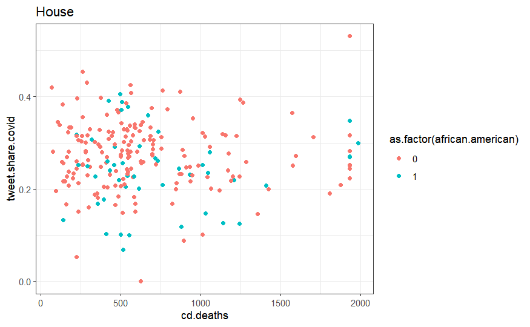

HOUSE MEMBER FACTORS

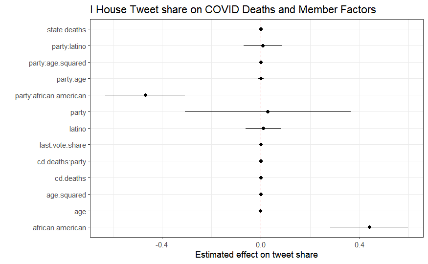

```r
# HOUSE MEMBER FACTORS WITH ORIGINAL INTERACTIONS

h3_lm_House_i <- lm(tweet.share.covid ~ cd.deaths + state.deaths + last.vote.share + party*(cd.deaths + age + age.squared + latino + african.american),
             data=tweet.totals.official %>% filter(chamber=="House"))

hm_estimates <- plotify(h3_lm_House_i)

ggplot(hm_estimates, aes(x=term, y=estimate))+
  geom_point()+
  geom_hline(yintercept = 0, colour = "red", lty = 2) +
  geom_pointrange(aes(ymin = conf.low, ymax = conf.high), size=.2)+
  labs(title = "I House Tweet share on COVID Deaths and Member Factors", y="Estimated effect on tweet share", x="") +
  coord_flip() +
  theme_bw()
```

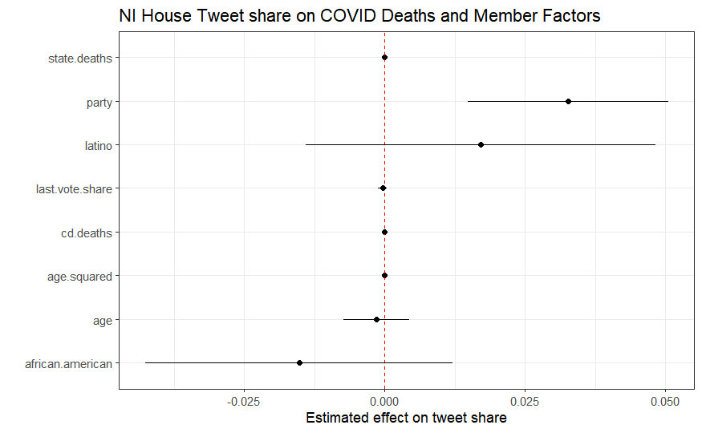

```r
# HOUSE MEMBER FACTORS NO INTERACTIONS

h3_lm_House_ni <- lm(tweet.share.covid ~ cd.deaths + state.deaths + party + age + age.squared + latino + african.american + last.vote.share,
             data=tweet.totals.official %>% filter(chamber=="House"))

#hm_estimates <- bind_rows(lapply(h3_lm_House, plotify)) %>% mutate(term=names(models))
hm2_estimates <- plotify(h3_lm_House_ni)

ggplot(hm2_estimates, aes(x=term, y=estimate))+
  geom_point()+
  geom_hline(yintercept = 0, colour = "red", lty = 2) +
  geom_pointrange(aes(ymin = conf.low, ymax = conf.high), size=.2)+
  labs(title = "NI House Tweet share on COVID Deaths and Member Factors", y="Estimated effect on tweet share", x="") +
  coord_flip() +
  theme_bw()
```

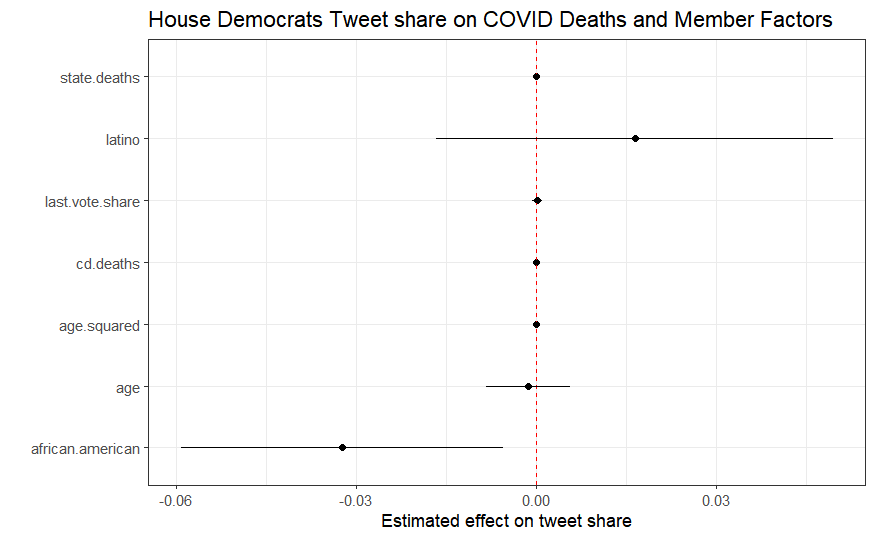

```r
# HOUSE DEMS MEMBER FACTORS NO INTERACTIONS

h3_lm_HD_ni <- lm(tweet.share.covid ~ cd.deaths + state.deaths + age + age.squared + latino + african.american + last.vote.share,
             data=tweet.totals.official %>% filter(chamber=="House", party==1))

#hm_estimates <- bind_rows(lapply(h3_lm_House, plotify)) %>% mutate(term=names(models))
hm3_estimates <- plotify(h3_lm_HD_ni)

ggplot(hm3_estimates, aes(x=term, y=estimate))+
  geom_point()+
  geom_hline(yintercept = 0, colour = "red", lty = 2) +
  geom_pointrange(aes(ymin = conf.low, ymax = conf.high), size=.2)+
  labs(title = "House Democrats Tweet share on COVID Deaths and Member Factors", y="Estimated effect on tweet share", x="") +
  coord_flip() +
  theme_bw()
```

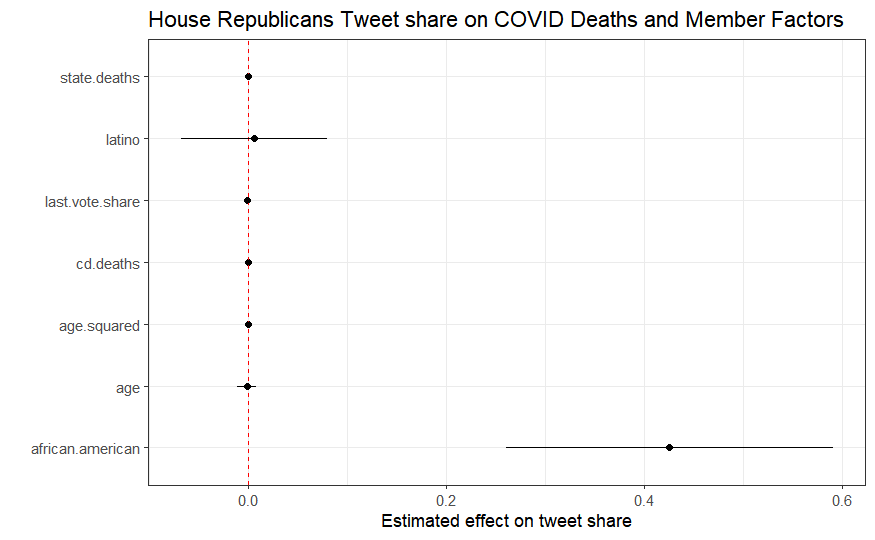

```r
# HOUSE GOP MEMBER FACTORS NO INTERACTIONS

h3_lm_HR_ni <- lm(tweet.share.covid ~ cd.deaths + state.deaths + age + age.squared + latino + african.american + last.vote.share,
             data=tweet.totals.official %>% filter(chamber=="House", party==0))

#hm_estimates <- bind_rows(lapply(h3_lm_House, plotify)) %>% mutate(term=names(models))
hm4_estimates <- plotify(h3_lm_HR_ni)

ggplot(hm4_estimates, aes(x=term, y=estimate))+
  geom_point()+
  geom_hline(yintercept = 0, colour = "red", lty = 2) +
  geom_pointrange(aes(ymin = conf.low, ymax = conf.high), size=.2)+
  labs(title = "House Republicans Tweet share on COVID Deaths and Member Factors", y="Estimated effect on tweet share", x="") +
  coord_flip() +
  theme_bw()
```

```r
NA
NA
```

HOUSE CONSTITUENCY FACTORS

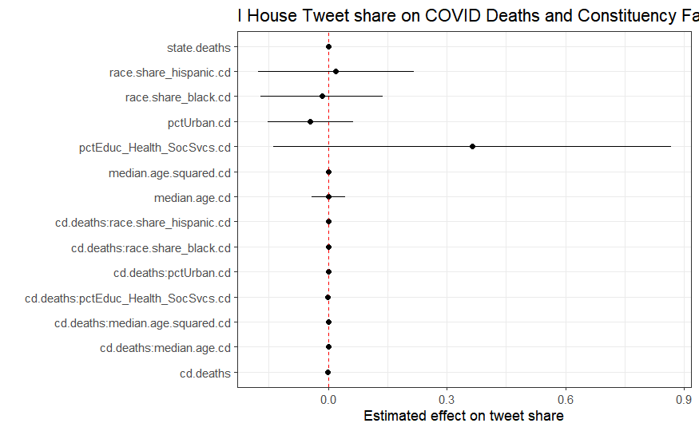

```r
# HOUSE CONSTITUENCY FACTORS WITH INTERACTIONS
h4_lm_House_i <- lm(tweet.share.covid ~ state.deaths + cd.deaths*(pctUrban.cd + median.age.cd + median.age.squared.cd + pctEduc_Health_SocSvcs.cd + race.share_hispanic.cd + race.share_black.cd),
   data=tweet.totals.official %>% filter(chamber=="House"))

#hm_estimates <- bind_rows(lapply(h3_lm_House, plotify)) %>% mutate(term=names(models))
hc_estimates <- plotify(h4_lm_House_i)

ggplot(hc_estimates, aes(x=term, y=estimate))+
  geom_point()+
  geom_hline(yintercept = 0, colour = "red", lty = 2) +
  geom_pointrange(aes(ymin = conf.low, ymax = conf.high), size=.2)+
  labs(title = "I House Tweet share on COVID Deaths and Constituency Factors", y="Estimated effect on tweet share", x="") +
  coord_flip() +
  theme_bw()
```

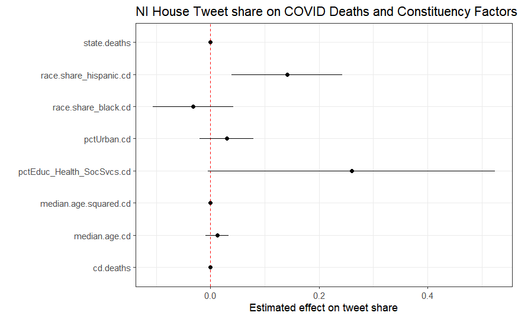

```r
# HOUSE CONSTITUENCY FACTORS NO INTERACTIONS

h4_lm_House_ni <- lm(tweet.share.covid ~ state.deaths + cd.deaths + pctUrban.cd + median.age.cd + median.age.squared.cd + pctEduc_Health_SocSvcs.cd + race.share_hispanic.cd + race.share_black.cd,
   data=tweet.totals.official %>% filter(chamber=="House"))

#hm_estimates <- bind_rows(lapply(h3_lm_House, plotify)) %>% mutate(term=names(models))
hc2_estimates <- plotify(h4_lm_House_ni)

ggplot(hc2_estimates, aes(x=term, y=estimate))+
  geom_point()+
  geom_hline(yintercept = 0, colour = "red", lty = 2) +
  geom_pointrange(aes(ymin = conf.low, ymax = conf.high), size=.2)+
  labs(title = "NI House Tweet share on COVID Deaths and Constituency Factors", y="Estimated effect on tweet share", x="") +
  coord_flip() +
  theme_bw()
```

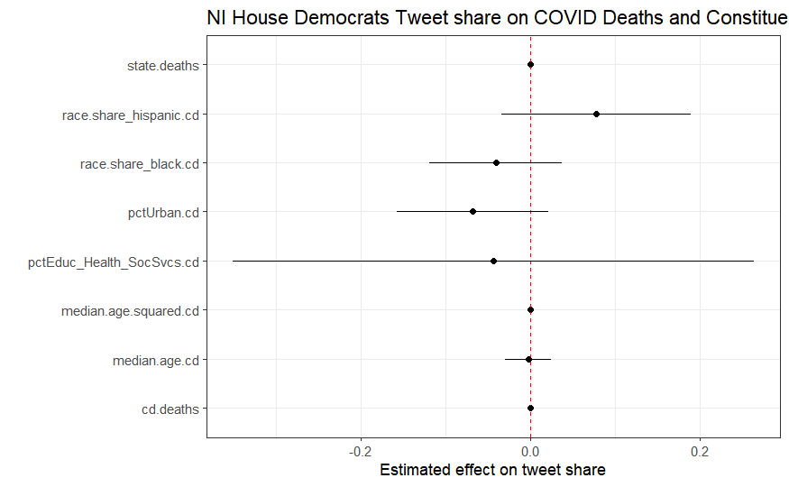

```r
# HOUSE DEMS CONSTITUENCY FACTORS NO INTERACTIONS

h4_lm_HD_ni <- lm(tweet.share.covid ~ state.deaths + cd.deaths + pctUrban.cd + median.age.cd + median.age.squared.cd + pctEduc_Health_SocSvcs.cd + race.share_hispanic.cd + race.share_black.cd,
             data=tweet.totals.official %>% filter(chamber=="House", party==1))

#hm_estimates <- bind_rows(lapply(h3_lm_House, plotify)) %>% mutate(term=names(models))
hc3_estimates <- plotify(h4_lm_HD_ni)

ggplot(hc3_estimates, aes(x=term, y=estimate))+
  geom_point()+
  geom_hline(yintercept = 0, colour = "red", lty = 2) +
  geom_pointrange(aes(ymin = conf.low, ymax = conf.high), size=.2)+
  labs(title = "NI House Democrats Tweet share on COVID Deaths and Constituency Factors", y="Estimated effect on tweet share", x="") +
  coord_flip() +
  theme_bw()
```

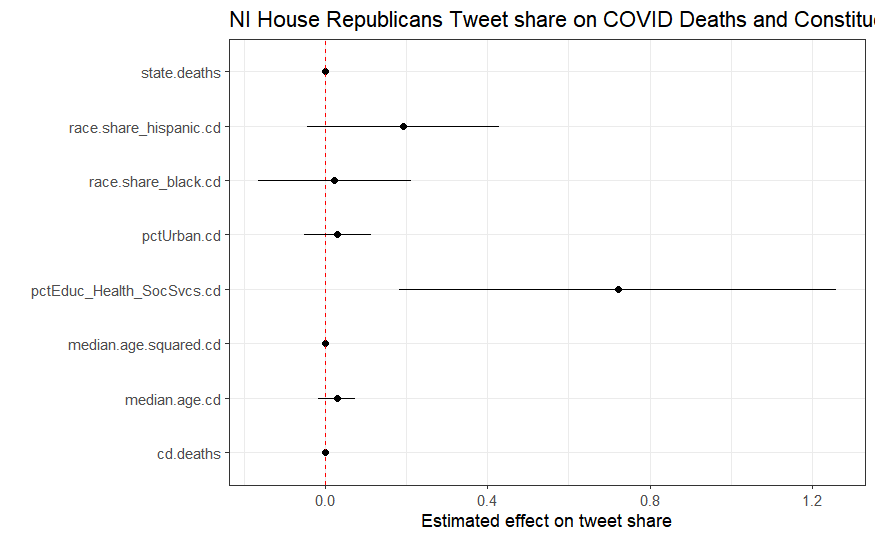

```r
# HOUSE GOP CONSTITUENCY FACTORS NO INTERACTIONS

h4_lm_HR_ni <- lm(tweet.share.covid ~ state.deaths + cd.deaths + pctUrban.cd + median.age.cd + median.age.squared.cd + pctEduc_Health_SocSvcs.cd + race.share_hispanic.cd + race.share_black.cd,
             data=tweet.totals.official %>% filter(chamber=="House", party==0))

#hm_estimates <- bind_rows(lapply(h3_lm_House, plotify)) %>% mutate(term=names(models))
hc4_estimates <- plotify(h4_lm_HR_ni)

ggplot(hc4_estimates, aes(x=term, y=estimate))+
  geom_point()+
  geom_hline(yintercept = 0, colour = "red", lty = 2) +
  geom_pointrange(aes(ymin = conf.low, ymax = conf.high), size=.2)+
  labs(title = "NI House Republicans Tweet share on COVID Deaths and Constituency Factors", y="Estimated effect on tweet share", x="") +
  coord_flip() +
  theme_bw()
```

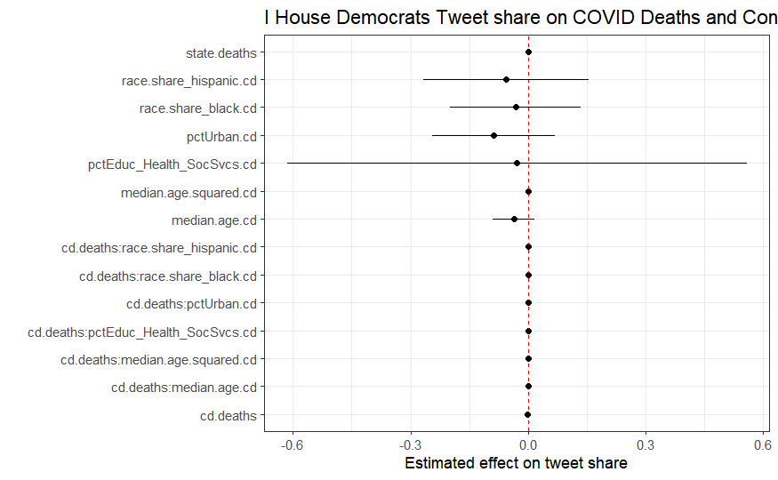

```r
h4_lm_HD_i <- lm(tweet.share.covid ~ state.deaths + cd.deaths*(pctUrban.cd + median.age.cd + median.age.squared.cd + pctEduc_Health_SocSvcs.cd + race.share_hispanic.cd + race.share_black.cd),
             data=tweet.totals.official %>% filter(chamber=="House", party==1))

#hm_estimates <- bind_rows(lapply(h3_lm_House, plotify)) %>% mutate(term=names(models))
hc5_estimates <- plotify(h4_lm_HD_i)

ggplot(hc5_estimates, aes(x=term, y=estimate))+
  geom_point()+
  geom_hline(yintercept = 0, colour = "red", lty = 2) +
  geom_pointrange(aes(ymin = conf.low, ymax = conf.high), size=.2)+
  labs(title = "I House Democrats Tweet share on COVID Deaths and Constituency Factors", y="Estimated effect on tweet share", x="") +
  coord_flip() +
  theme_bw()
```

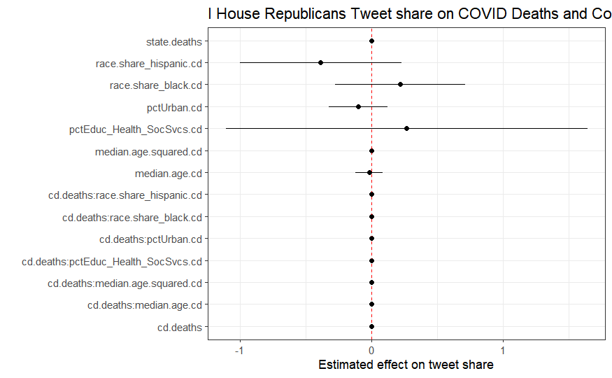

```r
# HOUSE GOP CONSTITUENCY FACTORS NO INTERACTIONS

h4_lm_HR_i <- lm(tweet.share.covid ~ state.deaths + cd.deaths*(pctUrban.cd + median.age.cd + median.age.squared.cd + pctEduc_Health_SocSvcs.cd + race.share_hispanic.cd + race.share_black.cd),
             data=tweet.totals.official %>% filter(chamber=="House", party==0))

#hm_estimates <- bind_rows(lapply(h3_lm_House, plotify)) %>% mutate(term=names(models))
hc6_estimates <- plotify(h4_lm_HR_i)

ggplot(hc6_estimates, aes(x=term, y=estimate))+
  geom_point()+
  geom_hline(yintercept = 0, colour = "red", lty = 2) +
  geom_pointrange(aes(ymin = conf.low, ymax = conf.high), size=.2)+
  labs(title = "I House Republicans Tweet share on COVID Deaths and Constituency Factors", y="Estimated effect on tweet share", x="") +
  coord_flip() +
  theme_bw()
```

HOUSE MEMBER AND CONSTITUENCY FACTORS

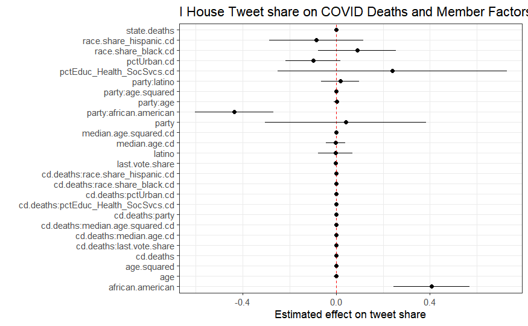

```r
# HOUSE ALL FACTORS WITH INTERACTIONS

h3h4_lm_House_i <- lm(tweet.share.covid ~ cd.deaths + state.deaths + party*(cd.deaths + age + age.squared + latino + african.american) + cd.deaths*(last.vote.share + pctUrban.cd + median.age.cd + median.age.squared.cd + pctEduc_Health_SocSvcs.cd + race.share_hispanic.cd + race.share_black.cd),
             data=tweet.totals.official %>% filter(chamber=="House"))

#hm_estimates <- bind_rows(lapply(h3_lm_House, plotify)) %>% mutate(term=names(models))
ha_estimates <- plotify(h3h4_lm_House_i)

ggplot(ha_estimates, aes(x=term, y=estimate))+
  geom_point()+
  geom_hline(yintercept = 0, colour = "red", lty = 2) +
  geom_pointrange(aes(ymin = conf.low, ymax = conf.high), size=.2)+
  labs(title = "I House Tweet share on COVID Deaths and Member Factors", y="Estimated effect on tweet share", x="") +
  coord_flip() +
  theme_bw()
```

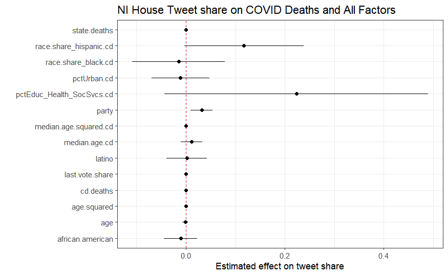

```r
# HOUSE ALL FACTORS NO INTERACTIONS

h3h4_lm_House_ni <- lm(tweet.share.covid ~ cd.deaths + state.deaths + party + age + age.squared + latino + african.american + last.vote.share +  pctUrban.cd + median.age.cd + median.age.squared.cd + pctEduc_Health_SocSvcs.cd + race.share_hispanic.cd + race.share_black.cd,
             data=tweet.totals.official %>% filter(chamber=="House"))

#hm_estimates <- bind_rows(lapply(h3_lm_House, plotify)) %>% mutate(term=names(models))
ha2_estimates <- plotify(h3h4_lm_House_ni)

ggplot(ha2_estimates, aes(x=term, y=estimate))+
  geom_point()+
  geom_hline(yintercept = 0, colour = "red", lty = 2) +
  geom_pointrange(aes(ymin = conf.low, ymax = conf.high), size=.2)+
  labs(title = "NI House Tweet share on COVID Deaths and All Factors", y="Estimated effect on tweet share", x="") +
  coord_flip() +
  theme_bw()
```

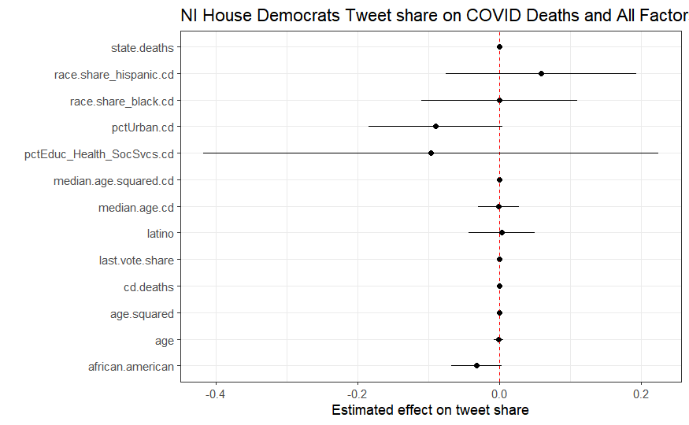

```r
# HOUSE DEMS MEMBER FACTORS NO INTERACTIONS

h3h4_lm_HD_ni <- lm(tweet.share.covid ~ cd.deaths + state.deaths + age + age.squared + latino + african.american + last.vote.share + pctUrban.cd + median.age.cd + median.age.squared.cd + pctEduc_Health_SocSvcs.cd + race.share_hispanic.cd + race.share_black.cd,
             data=tweet.totals.official %>% filter(chamber=="House", party==1))

#hm_estimates <- bind_rows(lapply(h3_lm_House, plotify)) %>% mutate(term=names(models))
ha3_estimates <- plotify(h3h4_lm_HD_ni)

ggplot(ha3_estimates, aes(x=term, y=estimate))+
  geom_point()+
  geom_hline(yintercept = 0, colour = "red", lty = 2) +
  geom_pointrange(aes(ymin = conf.low, ymax = conf.high), size=.2)+
  labs(title = "NI House Democrats Tweet share on COVID Deaths and All Factors", y="Estimated effect on tweet share", x="") +
  coord_flip() +
  theme_bw()
```

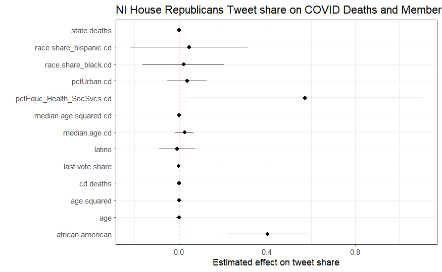

```r
# HOUSE GOP MEMBER FACTORS NO INTERACTIONS

h3h4_lm_HR_ni <- lm(tweet.share.covid ~ cd.deaths + state.deaths + age + age.squared + latino + african.american + last.vote.share + pctUrban.cd + median.age.cd + median.age.squared.cd + pctEduc_Health_SocSvcs.cd + race.share_hispanic.cd + race.share_black.cd,
             data=tweet.totals.official %>% filter(chamber=="House", party==0))

#hm_estimates <- bind_rows(lapply(h3_lm_House, plotify)) %>% mutate(term=names(models))
ha4_estimates <- plotify(h3h4_lm_HR_ni)

ggplot(ha4_estimates, aes(x=term, y=estimate))+
  geom_point()+
  geom_hline(yintercept = 0, colour = "red", lty = 2) +
  geom_pointrange(aes(ymin = conf.low, ymax = conf.high), size=.2)+
  labs(title = "NI House Republicans Tweet share on COVID Deaths and Member Factors", y="Estimated effect on tweet share", x="") +
  coord_flip() +
  theme_bw()
```

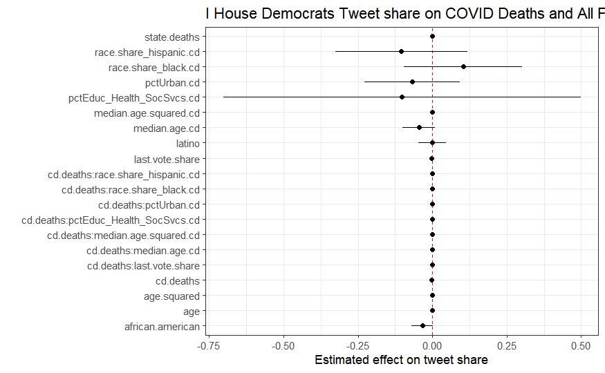

```r
# HOUSE DEMS MEMBER FACTORS INTERACTIONS

h3h4_lm_HD_i <- lm(tweet.share.covid ~ cd.deaths + state.deaths + age + age.squared + latino + african.american + cd.deaths*(last.vote.share + pctUrban.cd + median.age.cd + median.age.squared.cd + pctEduc_Health_SocSvcs.cd + race.share_hispanic.cd + race.share_black.cd),
             data=tweet.totals.official %>% filter(chamber=="House", party==1))

#hm_estimates <- bind_rows(lapply(h3_lm_House, plotify)) %>% mutate(term=names(models))
ha3_estimates <- plotify(h3h4_lm_HD_i)

ggplot(ha3_estimates, aes(x=term, y=estimate))+
  geom_point()+
  geom_hline(yintercept = 0, colour = "red", lty = 2) +
  geom_pointrange(aes(ymin = conf.low, ymax = conf.high), size=.2)+
  labs(title = "I House Democrats Tweet share on COVID Deaths and All Factors", y="Estimated effect on tweet share", x="") +
  coord_flip() +
  theme_bw()
```

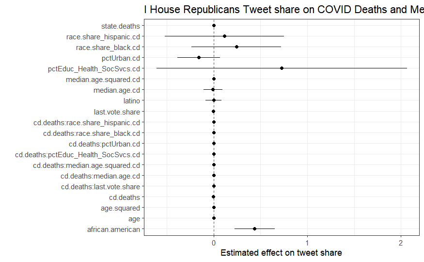

```r
# HOUSE GOP MEMBER FACTORS INTERACTIONS

h3h4_lm_HR_i <- lm(tweet.share.covid ~ cd.deaths + state.deaths + age + age.squared + latino + african.american + cd.deaths*(last.vote.share + pctUrban.cd + median.age.cd + median.age.squared.cd + pctEduc_Health_SocSvcs.cd + race.share_hispanic.cd + race.share_black.cd),
             data=tweet.totals.official %>% filter(chamber=="House", party==0))

#hm_estimates <- bind_rows(lapply(h3_lm_House, plotify)) %>% mutate(term=names(models))
ha4_estimates <- plotify(h3h4_lm_HR_i)

ggplot(ha4_estimates, aes(x=term, y=estimate))+
  geom_point()+
  geom_hline(yintercept = 0, colour = "red", lty = 2) +
  geom_pointrange(aes(ymin = conf.low, ymax = conf.high), size=.2)+
  labs(title = "I House Republicans Tweet share on COVID Deaths and Member Factors", y="Estimated effect on tweet share", x="") +
  coord_flip() +
  theme_bw()
```

HOUSE COEF PLOT COMBINED

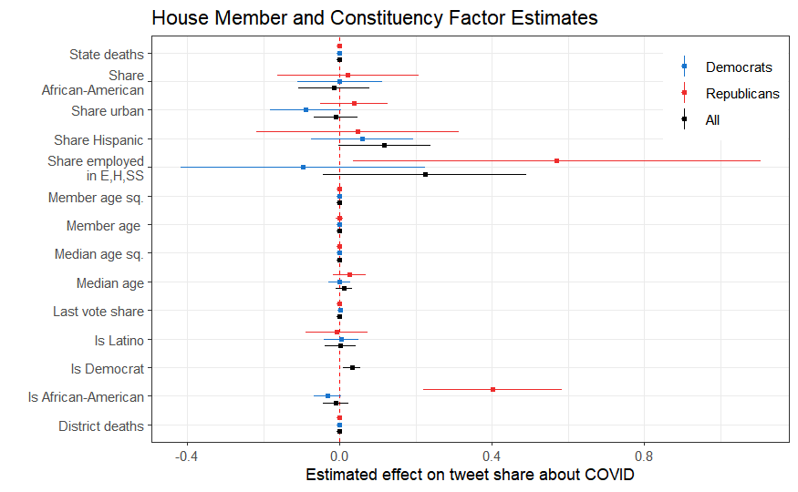

```r
house_plot_models <- list("All"=h3h4_lm_House_ni, "Democrats"=h3h4_lm_HD_ni, "Republicans"=h3h4_lm_HR_ni)

house_estimates <- bind_rows(lapply(house_plot_models, plotify), .id="variable") %>%
  mutate(label=recode(term, "state.deaths"="State deaths",
                                  "race.share_hispanic.cd"="Share Hispanic",
                                  "race.share_black.cd"="Share\nAfrican-American",
                                  "pctUrban.cd"="Share urban",
                                  "pctEduc_Health_SocSvcs.cd"="Share employed\nin E,H,SS",
                                  "median.age.squared.cd"="Median age sq.",
                                  "median.age.cd"="Median age",
                                  "latino"="Is Latino",
                                  "last.vote.share"="Last vote share",
                                  "cd.deaths"="District deaths",
                                  "age.squared"="Member age sq.",
                                  "age"="Member age ",
                                  "african.american"="Is African-American",
                                  "party"="Is Democrat"))

# ggplot(house_estimates %>% filter(variable=="House"), aes(x=term, y=estimate))+
#   geom_point(position = position_dodge(width = 1))+
#   geom_hline(yintercept = 0, colour = "red", lty = 2) +
#   geom_pointrange(aes(ymin = conf.low, ymax = conf.high), size=.2,
#                   position = position_dodge(width = 1))+
#   labs(title = "House Member and Constituency Factor Estimates",
#        y="Estimated effect on tweet share about COVID", x="") +
#   scale_x_discrete(labels=c("State deaths",
#                                   "Share Hispanic",
#                                   "Share African-American",
#                                   "Share urban",
#                                   "Share employed in E,H,SS",
#                                   "Is Democrat",
#                                   "Median age",
#                                   "Median age sq.",
#                                   "Is member Latino",
#                                   "Last vote share",
#                                   "District deaths",
#                                   "Is Latino",
#                                   "Member age",
#                                   "Member age sq.",
#                                   "Is African-American")) +
#   coord_flip() +
#   theme_bw()
#
# ggplot(house_estimates %>% filter(variable != "House"), aes(x=term, y=estimate, color=variable))+
#   geom_hline(yintercept = 0, colour = "red", lty = 2) +
#   geom_point(position = position_dodge(width = 0.4))+
#   geom_pointrange(aes(ymin = conf.low, ymax = conf.high), size=.2,
#                   position = position_dodge(width = 0.4)) +
#   labs(title = "House Member and Constituency Factor Estimates by Party",
#        y="Estimated effect on tweet share about COVID", x="") +
#   coord_flip() +
#   # scale_x_discrete(labels=c("State deaths",
#   #                                 "Share Hispanic",
#   #                                 "Share African-American",
#   #                                 "Share Urban",
#   #                                 "Share Employed in E,H,SS",
#   #                                 "Median age sq.",
#   #                                 "Median age",
#   #                                 "Is member Latino",
#   #                                 "Last vote share",
#   #                                 "District deaths",
#   #                                 "Is Latino",
#   #                                 "Member age sq.",
#   #                                 "Member age ",
#   #                                 "Is African-American")) +
#   theme_bw() +
#   theme(
#     legend.title=element_blank()
#   ) +
#   scale_color_manual(values=c("House Dems"="dodgerblue3", "House GOP"="firebrick2"))

ggplot(house_estimates, aes(x=label, y=estimate, color=variable))+
  geom_hline(yintercept = 0, colour = "red", lty = 2) +
  geom_point(position = position_dodge(width = 0.7), size=0.18)+
  geom_pointrange(aes(ymin = conf.low, ymax = conf.high), size=0.18,
                  position = position_dodge(width = 0.7)) +
  labs(title = "House Member and Constituency Factor Estimates",
       y="Estimated effect on tweet share about COVID", x="") +
  coord_flip() +
  # scale_x_discrete(labels=c("State deaths",
  #                                 "Share Hispanic",
  #                                 "Share African-American",
  #                                 "Share Urban",
  #                                 "Share Employed in E,H,SS",
  #                                 "Median age",
  #                                 "Median age sq.",
  #                                 "Is member Latino",
  #                                 "Last vote share",
  #                                 "District deaths",
  #                                 "Is Latino",
  #                                 "Member age",
  #                                 "Member age sq.",
  #                                 "Is African-American")) +
  theme_bw() +
  theme(
    legend.title=element_blank(),
    legend.position=c(0.9, 0.87)
  ) +
  scale_color_manual(values=c("Democrats"="dodgerblue3", "Republicans"="firebrick2", "All"="black"))
```

```r
NA
```

HOUSE REGRESSION TABLES

```r
modelsummary(list("Member factors"=h3_lm_House_ni,
                  "Member factors (interactions)"=h3_lm_House_i,
                  "Constituency factors"=h4_lm_House_ni,
                  "Constituency factors (interactions)"=h4_lm_House_i,
                  "All factors"=h3h4_lm_House_ni,
                  "All factors (interactions)"=h3h4_lm_House_i),
             coef_omit="(Intercept)",
             gof_omit="AIC|BIC|Log.Lik.|F", estimate="{estimate} ({std.error}){stars}",
             statistic=NULL, stars=c('+'=0.1,'*'=.05, '**'=.01, '***'=0.001),
             title="Share of Tweets About COVID-19 (House)
             &nbsp; &nbsp; &nbsp; &nbsp; &nbsp; &nbsp; &nbsp; p-values: + = 0.1, * = 0.05, ** = 0.01, *** = 0.001", fmt = "%.0e",
             coef_rename = c(
               cd.deaths = "District COVID-19 deaths",
               state.deaths = "State COVID-19 deaths",
               party = "Is a Democrat",
               age = "Member age",
               age.squared = "Member age sq.",
               african.american = "Is member African-American",
               latino = "Is member Latino",
               "cd.deaths:party" = "District deaths*Democrat",
               "party:age" = "Democrat*Age",
               "party:age.squared" = "Democrat*Age sq.",
               "party:latino" = "Democrat*Member Latino",
               "party:african.american" = "Democrat*Member African-American",
               "last.vote.share" = "Last vote share",
               "pctUrban.cd" = "Share of urban households in district",
               "median.age.cd" = "Median age of district",
               "median.age.squared.cd" = "Median age sq.",
               "pctEduc_Health_SocSvcs.cd" = "Share of district employed in education, health, social services",
               "race.share_black.cd" = "Share of district African-American",
               "race.share_hispanic.cd" = "Share of district Hispanic",
               "cd.deaths:last.vote.share" = "District deaths*Last vote share",
               "cd.deaths:median.age.cd" = "District deaths*Median age",
               "cd.deaths:median.age.squared.cd" = "District deaths*Median age sq.",
               "cd.deaths:pctEduc_Health_SocSvcs.cd" = "District deaths*Share employed in E,H,SS",
               "cd.deaths:pctUrban.cd" = "District deaths*Share urban",
               "cd.deaths:race.share_hispanic.cd" = "District deaths*Share Hispanic",
               "cd.deaths:race.share_black.cd" = "District deaths*Share African-American",
               "pctUrban.cd:race.share_hispanic.cd" = "Share urban*Share Hispanic",
               "pctUrban.cd:race.share_black.cd" = "Share urban*Share African-American"
             )) %>% save_kable(file="Tables/CS_regressions/House_lm_all.png")

modelsummary(list("Member factors"=h3_lm_HR_ni,
                  "Constituency factors"=h4_lm_HR_ni,
                  "Constituency factors (interactions)"=h4_lm_HR_i,
                  "All factors"=h3h4_lm_HR_ni,
                  "All factors (interactions)"=h3h4_lm_HR_i),
             coef_omit="(Intercept)",
             gof_omit="AIC|BIC|Log.Lik.|F", estimate="{estimate} ({std.error}){stars}",
             statistic=NULL, stars=c('+'=0.1,'*'=.05, '**'=.01, '***'=0.001),
             title="Share of Tweets About COVID-19 (House Republicans)
             &nbsp; &nbsp; &nbsp; &nbsp; &nbsp; &nbsp; &nbsp; p-values: + = 0.1, * = 0.05, ** = 0.01, *** = 0.001", fmt = "%.0e",
             coef_rename = c(
               cd.deaths = "District COVID-19 deaths",
               state.deaths = "State COVID-19 deaths",
               party = "Is a Democrat",
               age = "Member age",
               age.squared = "Member age sq.",
               african.american = "Is member African-American",
               latino = "Is member Latino",
               "cd.deaths:party" = "District deaths*Democrat",
               "party:age" = "Democrat*Age",
               "party:age.squared" = "Democrat*Age sq.",
               "party:latino" = "Democrat*Member Latino",
               "party:african.american" = "Democrat*Member African-American",
               "last.vote.share" = "Last vote share",
               "pctUrban.cd" = "Share of urban households in district",
               "median.age.cd" = "Median age of district",
               "median.age.squared.cd" = "Median age sq.",
               "pctEduc_Health_SocSvcs.cd" = "Share of district employed in education, health, social services",
               "race.share_black.cd" = "Share of district African-American",
               "race.share_hispanic.cd" = "Share of district Hispanic",
               "cd.deaths:last.vote.share" = "District deaths*Last vote share",
               "cd.deaths:median.age.cd" = "District deaths*Median age",
               "cd.deaths:median.age.squared.cd" = "District deaths*Median age sq.",
               "cd.deaths:pctEduc_Health_SocSvcs.cd" = "District deaths*Share employed in E,H,SS",
               "cd.deaths:pctUrban.cd" = "District deaths*Share urban",
               "cd.deaths:race.share_hispanic.cd" = "District deaths*Share Hispanic",
               "cd.deaths:race.share_black.cd" = "District deaths*Share African-American",
               "pctUrban.cd:race.share_hispanic.cd" = "Share urban*Share Hispanic",
               "pctUrban.cd:race.share_black.cd" = "Share urban*Share African-American"
             )) %>% save_kable(file="Tables/CS_regressions/House_R_lm_all.png")

modelsummary(list("Member factors"=h3_lm_HD_ni,
                  "Constituency factors"=h4_lm_HR_ni,
                  "Constituency factors (interactions)"=h4_lm_HD_i,
                  "All factors"=h3h4_lm_HD_ni,
                  "All factors (interactions)"=h3h4_lm_HD_i),
             coef_omit="(Intercept)",
             gof_omit="AIC|BIC|Log.Lik.|F", estimate="{estimate} ({std.error}){stars}",
             statistic=NULL, stars=c('+'=0.1,'*'=.05, '**'=.01, '***'=0.001),
             title="Share of Tweets About COVID-19 (House Democrats)
             &nbsp; &nbsp; &nbsp; &nbsp; &nbsp; &nbsp; &nbsp; p-values: + = 0.1, * = 0.05, ** = 0.01, *** = 0.001", fmt = "%.0e",
             coef_rename = c(
               cd.deaths = "District COVID-19 deaths",
               state.deaths = "State COVID-19 deaths",
               party = "Is a Democrat",
               age = "Member age",
               age.squared = "Member age sq.",
               african.american = "Is member African-American",
               latino = "Is member Latino",
               "cd.deaths:party" = "District deaths*Democrat",
               "party:age" = "Democrat*Age",
               "party:age.squared" = "Democrat*Age sq.",
               "party:latino" = "Democrat*Member Latino",
               "party:african.american" = "Democrat*Member African-American",
               "last.vote.share" = "Last vote share",
               "pctUrban.cd" = "Share of urban households in district",
               "median.age.cd" = "Median age of district",
               "median.age.squared.cd" = "Median age sq.",
               "pctEduc_Health_SocSvcs.cd" = "Share of district employed in education, health, social services",
               "race.share_black.cd" = "Share of district African-American",
               "race.share_hispanic.cd" = "Share of district Hispanic",
               "cd.deaths:last.vote.share" = "District deaths*Last vote share",
               "cd.deaths:median.age.cd" = "District deaths*Median age",
               "cd.deaths:median.age.squared.cd" = "District deaths*Median age sq.",
               "cd.deaths:pctEduc_Health_SocSvcs.cd" = "District deaths*Share employed in E,H,SS",
               "cd.deaths:pctUrban.cd" = "District deaths*Share urban",
               "cd.deaths:race.share_hispanic.cd" = "District deaths*Share Hispanic",
               "cd.deaths:race.share_black.cd" = "District deaths*Share African-American",
               "pctUrban.cd:race.share_hispanic.cd" = "Share urban*Share Hispanic",
               "pctUrban.cd:race.share_black.cd" = "Share urban*Share African-American"
             )) %>% save_kable(file="Tables/CS_regressions/House_D_lm_all.png")
```

House Dems AA effect spec curve

```r
# estimation function
spec_curve_ests2 <-
  function(
    x = NULL,
    controls = NULL) {

  if(controls == "") {plus <- ""} else {plus <- "+"}

      frm <-
        as.formula(paste0("tweet.share.covid ~", x, plus, controls))

      out <-
        #feols(frm, cluster = ~svy_sh_tsp_code, data = analysis_df) %>%
        lm(frm, data=tweet.totals.official %>% filter(party==1)) %>%
        tidy(conf.int = T) %>%
        mutate(control_set = as.character(controls))

    }

run_models2 <- function(IV=NULL, controls=NULL){
  # all unique control combinations (i.e. powerset, including the empty set)
  # adapted from:
  # https://stackoverflow.com/questions/49570793/r-list-all-combinations-with-combn-multiple-m-values
  control_list <- data.frame(
    x = IV,
    controls = list(
      do.call("c", lapply(seq_along(controls),
                          function(i) utils::combn(controls,
                                                   i, FUN = list))) %>%
      map(function(x) paste(x, collapse = " + ")), "") %>%
      unlist())

  res <- pmap_dfr(control_list, .f = spec_curve_ests2) %>%
    filter(term == IV) %>%
    arrange(estimate) %>%
    mutate(specifications = 1:nrow(.))

  return(res)
}

h3h4_lm_HD_controls <-
  c("state.deaths", "cd.deaths", "age", "age.squared", "latino", "last.vote.share", "pctUrban.cd",
    "median.age.cd", "median.age.squared.cd", "pctEduc_Health_SocSvcs.cd", "race.share_hispanic.cd",
    "race.share_black.cd", "pctUrban.cd", "cd.deaths:pctUrban.cd", "cd.deaths:african.american")

h3h4_HD_AA_spec <- run_models2(IV="african.american", controls=h3h4_lm_HD_controls)

# plot top panel
sc7 <-
  h3h4_HD_AA_spec %>%
  ggplot(aes(x = specifications, y = estimate)) +
    #geom_pointrange(size=0.25) +
    geom_point(size=0.1) +
    geom_ribbon(aes(ymin = conf.low, ymax = conf.high), fill="red", col=NA, alpha=0.15) +
    labs(x = "", y = "Is Member AA Coefficient Estimate",
         title="Dem African-American Rep. Specification Curve Analysis") +
    geom_hline(yintercept = 0, color = "darkblue") +
    theme_bw() +
    theme(
      axis.title.y = element_text(size=7),
      axis.text.y=element_text(size=7),
      title = element_text(size=8)
    )

# lower plot
sc8 <-
  expand.grid(control = h3h4_lm_HD_controls,
              specifications = c(1:max(h3h4_HD_AA_spec$specifications))) %>%
  left_join(h3h4_HD_AA_spec, by = "specifications") %>%
  mutate(value = ifelse(str_detect(control_set, as.character(control)), "|", "")) %>%
  ggplot(aes(specifications, control)) +
    geom_text(aes(label = value), size=0.75) +
    scale_color_manual(values = c("lightblue")) +
    labs(x = "Specification number", y = "") +
    # scale_y_discrete(labels=rev(c("District deaths*Share urban",
    #                           "Is Democrat*Member age",
    #                           "Share AA",
    #                           "Share Hispanic",
    #                           "Share in E,H,SS",
    #                           "Median age",
    #                           "Share urban",
    #                           "Vote share won",
    #                           "Is AA",
    #                           "Is Latino",
    #                           "Member age",
    #                           "Is Democrat",
    #                           "State deaths"))) +
    theme_bw() +
    theme(
        axis.text.y=element_text(size=5.5)
      )

#grid.arrange(sc3, sc4)

grid::grid.newpage()
grid::grid.draw(rbind(ggplotGrob(sc7), ggplotGrob(sc8)))
```

House tweet share dist by race

```r
# ggplot(data=tweet.totals.official %>%
#          mutate(african.american=recode(african.american, `1`="African-American", `0`="Not African-American")) %>%
#          select(tweet.share.covid, african.american, party, chamber) %>%  drop_na() %>%  filter(chamber=="House"),
#        aes(x=tweet.share.covid, fill=as.factor(african.american))) +
#   geom_density(color="black", alpha=0.75) +
#   labs(x="Share of tweets about COVID-19",y="", title="House Both Parties") +
#   theme_bw() +
#   theme(
#     legend.title = element_blank(),
#     legend.position = c(0.85, 0.85)
#   ) +
#   scale_fill_manual(values=c("African-American"="cornflowerblue", "Not African-American"="limegreen"))
#
# ggplot(data=tweet.totals.official %>%
#          mutate(african.american=recode(african.american, `1`="African-American", `0`="Not African-American")) %>%
#          select(total.covid.tweets, african.american, party, chamber) %>%  drop_na() %>%  filter(chamber=="House", party==1),
#        aes(x=total.covid.tweets, fill=as.factor(african.american))) +
#   geom_density(color="black", alpha=0.75) +
#   labs(x="Total tweets about COVID-19",y="", title="House Democrats") +
#   theme_bw() +
#   theme(
#     legend.title = element_blank(),
#     legend.position = c(0.83, 0.88)
#   ) +
#   scale_fill_manual(values=c("African-American"="cornflowerblue", "Not African-American"="limegreen"))
#   #facet_wrap(~party) +
#   #scale_fill_manual(values=c("Democrats"="navyblue", "Republicans"="darkred")) +
#   #theme(legend.position="none")
#
#
# ggplot(data=tweet.totals.official %>%
#          mutate(african.american=recode(african.american, `1`="African-American", `0`="Not African-American")) %>%
#          select(total.tweets, african.american, party, chamber) %>%  drop_na() %>%  filter(chamber=="House", party==1),
#        aes(x=total.tweets, fill=as.factor(african.american))) +
#   geom_density(color="black", alpha=0.75) +
#   labs(x="Total tweets",y="", title="House Democrats") +
#   theme_bw() +
#   theme(
#     legend.title = element_blank(),
#     legend.position = c(0.85, 0.85)
#   ) +
#   scale_fill_manual(values=c("African-American"="cornflowerblue", "Not African-American"="limegreen"))

# POLISHED PLOTS

twc_mean_D_AA <- mean((tweet.totals.official %>% filter(chamber=="House", party==1, african.american==1))$tweet.share.covid)

twc_mean_D_nAA <- mean((tweet.totals.official %>% filter(chamber=="House", party==1, african.american==0))$tweet.share.covid)

ggplot(data=tweet.totals.official %>%
         mutate(african.american=recode(african.american, `1`="African-American", `0`="Not African-American")) %>%
         select(tweet.share.covid, african.american, party, chamber) %>%
         drop_na() %>%  filter(chamber=="House", party==1),
       aes(x=tweet.share.covid, fill=as.factor(african.american))) +
  geom_density(color="black", alpha=0.75) +
  geom_vline(xintercept=twc_mean_D_AA, color="navyblue", linetype="dashed", size=0.75) +
  geom_vline(xintercept=twc_mean_D_nAA, color="darkgreen", linetype="dashed", size=0.75) +
  labs(x="Share of tweets about COVID-19",y="", title="House Democrats Tweet Share Distribution by Race") +
  theme_bw() +
  theme(
    legend.title = element_blank(),
    legend.position = c(0.83, 0.88)
  ) +
  scale_fill_manual(values=c("African-American"="cornflowerblue", "Not African-American"="limegreen"),
                    labels=c(paste("African-American (μ = ", round(twc_mean_D_AA, 2), ")", sep=""),
                             paste("Not African-American (μ = ", round(twc_mean_D_nAA, 2), ")", sep="")))


twc_mean_D_L <- mean((tweet.totals.official %>% filter(chamber=="House", party==1, latino==1))$tweet.share.covid)

twc_mean_D_nL <- mean((tweet.totals.official %>% filter(chamber=="House", party==1, latino==0))$tweet.share.covid)

ggplot(data=tweet.totals.official %>%
         mutate(latino=recode(latino, `1`="Latino", `0`="Not Latino")) %>%
         select(tweet.share.covid, latino, party, chamber) %>%
         drop_na() %>%  filter(chamber=="House", party==1),
       aes(x=tweet.share.covid, fill=as.factor(latino))) +
  geom_density(color="black", alpha=0.75) +
  geom_vline(xintercept=twc_mean_D_L, color="navyblue", linetype="dashed", size=0.75) +
  geom_vline(xintercept=twc_mean_D_nL, color="darkgreen", linetype="dashed", size=0.75) +
  labs(x="Share of tweets about COVID-19",y="", title="House Democrats Tweet Share Distribution by Race") +
  theme_bw() +
  theme(
    legend.title = element_blank(),
    legend.position = c(0.83, 0.88)
  ) +
  scale_fill_manual(values=c("Latino"="cornflowerblue", "Not Latino"="limegreen"),
                    labels=c(paste("Latino (μ = ", round(twc_mean_D_L, 2), ")", sep=""),
                             paste("Not Latino (μ = ", round(twc_mean_D_nL, 2), ")", sep="")))

twc_mean_R_L <- mean((tweet.totals.official %>% filter(chamber=="House", party==0, latino==1))$tweet.share.covid)

twc_mean_R_nL <- mean((tweet.totals.official %>% filter(chamber=="House", party==0, latino==0))$tweet.share.covid)

ggplot(data=tweet.totals.official %>%
         mutate(latino=recode(latino, `1`="Latino", `0`="Not Latino")) %>%
         select(tweet.share.covid, latino, party, chamber) %>%
         drop_na() %>%  filter(chamber=="House", party==0),
       aes(x=tweet.share.covid, fill=as.factor(latino))) +
  geom_density(color="black", alpha=0.75) +
  geom_vline(xintercept=twc_mean_D_L, color="navyblue", linetype="dashed", size=0.75) +
  geom_vline(xintercept=twc_mean_D_nL, color="darkgreen", linetype="dashed", size=0.75) +
  labs(x="Share of tweets about COVID-19",y="", title="House Republicans Tweet Share Distribution by Race") +
  theme_bw() +
  theme(
    legend.title = element_blank(),
    legend.position = c(0.83, 0.88)
  ) +
  scale_fill_manual(values=c("Latino"="cornflowerblue", "Not Latino"="limegreen"),
                    labels=c(paste("Latino (μ = ", round(twc_mean_D_L, 2), ")", sep=""),
                             paste("Not Latino (μ = ", round(twc_mean_D_nL, 2), ")", sep="")))


twc_mean_D_AAL <- mean((tweet.totals.official %>% filter(chamber=="House", party==1, aa.or.lat==1))$tweet.share.covid)

twc_mean_D_nAAL <- mean((tweet.totals.official %>% filter(chamber=="House", party==1, aa.or.lat==0))$tweet.share.covid)

ggplot(data=tweet.totals.official %>%
         mutate(aa.or.lat=recode(aa.or.lat, `1`="AA or Latino", `0`="Not AA or Latino")) %>%
         select(tweet.share.covid, aa.or.lat, party, chamber) %>%
         drop_na() %>%  filter(chamber=="House", party==1),
       aes(x=tweet.share.covid, fill=as.factor(aa.or.lat))) +
  geom_density(color="black", alpha=0.75) +
  geom_vline(xintercept=twc_mean_D_AAL, color="navyblue", linetype="dashed", size=0.75) +
  geom_vline(xintercept=twc_mean_D_nAAL, color="darkgreen", linetype="dashed", size=0.75) +
  labs(x="Share of tweets about COVID-19",y="", title="House Democrats Tweet Share Distribution by Race") +
  theme_bw() +
  theme(
    legend.title = element_blank(),
    legend.position = c(0.83, 0.88)
  ) +
  scale_fill_manual(values=c("AA or Latino"="cornflowerblue", "Not AA or Latino"="limegreen"),
                    labels=c(paste("AA or Latino (μ = ", round(twc_mean_D_AAL, 2), ")", sep=""),
                             paste("Not AA or Latino (μ = ", round(twc_mean_D_nAAL, 2), ")", sep="")))

twc_mean_AAL <- mean((tweet.totals.official %>% filter(chamber=="House", aa.or.lat==1))$tweet.share.covid)

twc_mean_nAAL <- mean((tweet.totals.official %>% filter(chamber=="House", aa.or.lat==0))$tweet.share.covid)

ggplot(data=tweet.totals.official %>%
         mutate(aa.or.lat=recode(aa.or.lat, `1`="AA or Latino", `0`="Not AA or Latino")) %>%
         select(tweet.share.covid, aa.or.lat, party, chamber) %>%
         drop_na() %>%  filter(chamber=="House"),
       aes(x=tweet.share.covid, fill=as.factor(aa.or.lat))) +
  geom_density(color="black", alpha=0.75) +
  geom_vline(xintercept=twc_mean_D_AAL, color="navyblue", linetype="dashed", size=0.75) +
  geom_vline(xintercept=twc_mean_D_nAAL, color="darkgreen", linetype="dashed", size=0.75) +
  labs(x="Share of tweets about COVID-19",y="", title="House Tweet Share Distribution by Race") +
  theme_bw() +
  theme(
    legend.title = element_blank(),
    legend.position = c(0.83, 0.88)
  ) +
  scale_fill_manual(values=c("AA or Latino"="cornflowerblue", "Not AA or Latino"="limegreen"),
                    labels=c(paste("AA or Latino (μ = ", round(twc_mean_AAL, 2), ")", sep=""),
                             paste("Not AA or Latino (μ = ", round(twc_mean_nAAL, 2), ")", sep="")))
```

House tweet share dist by party

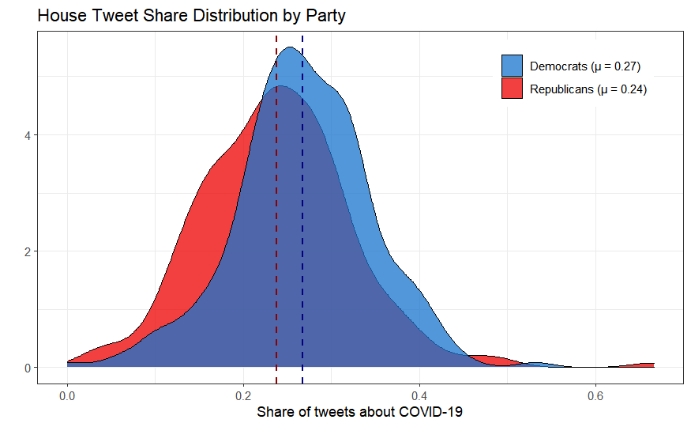

```r
twc_mean_HD <- mean((tweet.totals.official %>% filter(chamber=="House", party==1))$tweet.share.covid)

twc_mean_HR <- mean((tweet.totals.official %>% filter(chamber=="House", party==0))$tweet.share.covid)

ggplot(data=tweet.totals.official %>%
         select(tweet.share.covid, party, chamber) %>%
         drop_na() %>%  filter(chamber=="House"),
       aes(x=tweet.share.covid, fill=as.factor(party))) +
  geom_density(color="black", alpha=0.75) +
  geom_vline(xintercept=twc_mean_HD, color="navyblue", linetype="dashed", size=0.75) +
  geom_vline(xintercept=twc_mean_HR, color="darkred", linetype="dashed", size=0.75) +
  labs(x="Share of tweets about COVID-19",y="", title="House Tweet Share Distribution by Party") +
  theme_bw() +
  theme(
    legend.title = element_blank(),
    legend.position = c(0.83, 0.88)
  ) +
  scale_fill_manual(values=c(`1`="dodgerblue3", `0`="red2"),
                    labels=c(paste("Democrats (μ = ", round(twc_mean_HD, 2), ")", sep=""),
                             paste("Republicans (μ = ", round(twc_mean_HR, 2), ")", sep="")))
```

House interaction plots

```r
# DEATHS AND VOTE SHARE
fivenum((tweet.totals.official %>% filter(party==1, chamber=="House"))$last.vote.share)

plot_model(h3h4_lm_HD_i, type="pred",
           terms=c("cd.deaths", "last.vote.share [49, 100]")) +
  theme_bw() +
  labs(x="Total district COVID-19 deaths", y="Share of tweets about COVID-19",
       title="House Democrats Interaction Plot for Last Vote Share*District COVID-19 Deaths") +
  theme(
    legend.position = c(0.1, 0.85)
  ) +
  scale_color_manual("Last vote share",values = c(`49`="brown3", `100`="green4"),
                    labels = c("49%", "100%")) +
  scale_fill_manual(values = c(`49`="brown3", `100`="green4")) +
  ylim(0,0.5)

plot_model(h3h4_lm_HR_i, type="pred",
           terms=c("cd.deaths", "last.vote.share [49, 100]")) +
  theme_bw() +
  labs(x="Total district COVID-19 deaths", y="Share of tweets about COVID-19",
       title="House Republicans Interaction Plot for Last Vote Share*District COVID-19 Deaths") +
  theme(
    legend.position = c(0.1, 0.85)
  ) +
  scale_color_manual("Last vote share",values = c(`49`="brown3", `100`="green4"),
                    labels = c("49%", "100%")) +
  scale_fill_manual(values = c(`49`="brown3", `100`="green4"))

# DEATHS AND VOTE SHARE
#fivenum((tweet.totals.official %>% filter(party==1, chamber=="House"))$last.vote.share)

plot_model(h3h4_lm_House_i, type="pred",
           terms=c("cd.deaths", "last.vote.share [49, 100]")) +
  theme_bw() +
  labs(x="Total district COVID-19 deaths", y="Share of tweets about COVID-19",
       title="House Interaction Plot for Last Vote Share*District COVID-19 Deaths") +
  theme(
    legend.position = c(0.1, 0.85)
  ) +
  scale_color_manual("Last vote share",values = c(`49`="brown3", `100`="green4"),
                    labels = c("49%", "100%")) +
  scale_fill_manual(values = c(`49`="brown3", `100`="green4"))


ggplot(tweet.totals.official, aes(x=pctEduc_Health_SocSvcs.cd, y=cd.deaths)) +
  geom_point()

plot_model(lm(data=tweet.totals.official, cd.deaths ~ pctEduc_Health_SocSvcs.cd*pctUrban.cd), type="pred",
           terms=c("pctEduc_Health_SocSvcs.cd", "pctUrban.cd [0.25, 0.75, 1]")) +
  theme_bw()



plot_model(h4_lm_HD_ni, type="pred",
           terms=c("pctEduc_Health_SocSvcs.cd")) +
  theme_bw() +
  ylim(0,0.5)

plot_model(h3h4_lm_HR_i, type="pred",
           terms=c("pctEduc_Health_SocSvcs.cd")) +
  theme_bw() +
  ylim(0,0.5)

plot_model(h4_lm_House_ni, type="pred",
           terms=c("pctEduc_Health_SocSvcs.cd")) +
  theme_bw() +
  ylim(0,0.5)

plot_model(h4_lm_House_i, type="pred",
           terms=c("pctEduc_Health_SocSvcs.cd")) +
  theme_bw() +
  ylim(0,0.5)
```

House marginal effect plots

```r
plot_model(h3_lm_House_i, type="pred",
           terms=c("cd.deaths")) +
  theme_bw() +
  labs(x="Total district COVID-19 deaths", y="Share of tweets about COVID-19",
       title="House Marginal Effect of District COVID-19 Deaths on\nShare of Tweets about COVID-19 (Member Factors Model)")

plot_model(h3h4_lm_House_i, type="pred",
           terms=c("last.vote.share")) +
  theme_bw() +
  labs(x="Last vote share (%)", y="Share of tweets about COVID-19",
       title="House Marginal Effect of Last Vote Share on\nShare of Tweets about COVID-19") +
  ylim(0,0.5)


plot_model(h4_lm_HR_ni, type="pred",
           terms=c("pctEduc_Health_SocSvcs.cd")) +
  theme_bw() +
  labs(x="Share of district employed in education, health, social services",
       y="Share of tweets about COVID-19",
       title="House Republicans Marginal Effect of Share Employed in E,H,SS on\nShare of Tweets about COVID-19 (Constituency Factors, No Interactions)") +
  ylim(0,0.5)



plot_model(h4_lm_House_ni, type="pred",
           terms=c("race.share_hispanic.cd")) +
  theme_bw() +
  labs(x="Share of district Hispanic",
       y="Share of tweets about COVID-19",
       title="House Marginal Effect of Share of District Hispanic on\nShare of Tweets about COVID-19 (Constituency Factors, No Interactions)") +
  ylim(0,0.5)
```

## Senate

SENATE MEMBER FACTORS

```r
# SENATE MEMBER FACTORS WITH ORIGINAL INTERACTIONS

h3_lm_Senate_i <- lm(tweet.share.covid ~ state.deaths + last.vote.share + party*(state.deaths + age + age.squared + latino + african.american),
             data=tweet.totals.official %>% filter(chamber=="Senate"))

hm_estimates <- plotify(h3_lm_Senate_i)

ggplot(hm_estimates, aes(x=term, y=estimate))+
  geom_point()+
  geom_hline(yintercept = 0, colour = "red", lty = 2) +
  geom_pointrange(aes(ymin = conf.low, ymax = conf.high), size=.2)+
  labs(title = "I Senate Tweet share on COVID Deaths and Member Factors", y="Estimated effect on tweet share", x="") +
  coord_flip() +
  theme_bw()


# Senate MEMBER FACTORS NO INTERACTIONS

h3_lm_Senate_ni <- lm(tweet.share.covid ~ state.deaths + party + age + age.squared + latino + african.american + last.vote.share,
             data=tweet.totals.official %>% filter(chamber=="Senate"))

#hm_estimates <- bind_rows(lapply(h3_lm_Senate, plotify)) %>% mutate(term=names(models))
hm2_estimates <- plotify(h3_lm_Senate_ni)

ggplot(hm2_estimates, aes(x=term, y=estimate))+
  geom_point()+
  geom_hline(yintercept = 0, colour = "red", lty = 2) +
  geom_pointrange(aes(ymin = conf.low, ymax = conf.high), size=.2)+
  labs(title = "NI Senate Tweet share on COVID Deaths and Member Factors", y="Estimated effect on tweet share", x="") +
  coord_flip() +
  theme_bw()

# Senate DEMS MEMBER FACTORS NO INTERACTIONS

h3_lm_SD_ni <- lm(tweet.share.covid ~ state.deaths + age + age.squared + latino + african.american + last.vote.share,
             data=tweet.totals.official %>% filter(chamber=="Senate", party==1))

#hm_estimates <- bind_rows(lapply(h3_lm_Senate, plotify)) %>% mutate(term=names(models))
hm3_estimates <- plotify(h3_lm_SD_ni)

ggplot(hm3_estimates, aes(x=term, y=estimate))+
  geom_point()+
  geom_hline(yintercept = 0, colour = "red", lty = 2) +
  geom_pointrange(aes(ymin = conf.low, ymax = conf.high), size=.2)+
  labs(title = "Senate Democrats Tweet share on COVID Deaths and Member Factors", y="Estimated effect on tweet share", x="") +
  coord_flip() +
  theme_bw()

# Senate GOP MEMBER FACTORS NO INTERACTIONS

h3_lm_SR_ni <- lm(tweet.share.covid ~ state.deaths + state.deaths + age + age.squared + latino + african.american + last.vote.share,
             data=tweet.totals.official %>% filter(chamber=="Senate", party==0))

#hm_estimates <- bind_rows(lapply(h3_lm_Senate, plotify)) %>% mutate(term=names(models))
hm4_estimates <- plotify(h3_lm_SR_ni)

ggplot(hm4_estimates, aes(x=term, y=estimate))+
  geom_point()+
  geom_hline(yintercept = 0, colour = "red", lty = 2) +
  geom_pointrange(aes(ymin = conf.low, ymax = conf.high), size=.2)+
  labs(title = "Senate Republicans Tweet share on COVID Deaths and Member Factors", y="Estimated effect on tweet share", x="") +
  coord_flip() +
  theme_bw()
```

SENATE CONSTITUENCY FACTORS

```r
# Senate CONSTITUENCY FACTORS WITH INTERACTIONS
h4_lm_Senate_i <- lm(tweet.share.covid ~ state.deaths*(pctUrban.state + median.age.state + median.age.squared.state + pctEduc_Health_SocSvcs.state + race.share_hispanic.state + race.share_black.state),
   data=tweet.totals.official %>% filter(chamber=="Senate"))

#hm_estimates <- bind_rows(lapply(h3_lm_Senate, plotify)) %>% mutate(term=names(models))
hc_estimates <- plotify(h4_lm_Senate_i)

ggplot(hc_estimates, aes(x=term, y=estimate))+
  geom_point()+
  geom_hline(yintercept = 0, colour = "red", lty = 2) +
  geom_pointrange(aes(ymin = conf.low, ymax = conf.high), size=.2)+
  labs(title = "I Senate Tweet share on COVID Deaths and Constituency Factors", y="Estimated effect on tweet share", x="") +
  coord_flip() +
  theme_bw()


# Senate CONSTITUENCY FACTORS NO INTERACTIONS

h4_lm_Senate_ni <- lm(tweet.share.covid ~ state.deaths + pctUrban.state + median.age.state + median.age.squared.state + pctEduc_Health_SocSvcs.state + race.share_hispanic.state + race.share_black.state,
   data=tweet.totals.official %>% filter(chamber=="Senate"))

#hm_estimates <- bind_rows(lapply(h3_lm_Senate, plotify)) %>% mutate(term=names(models))
hc2_estimates <- plotify(h4_lm_Senate_ni)

ggplot(hc2_estimates, aes(x=term, y=estimate))+
  geom_point()+
  geom_hline(yintercept = 0, colour = "red", lty = 2) +
  geom_pointrange(aes(ymin = conf.low, ymax = conf.high), size=.2)+
  labs(title = "NI Senate Tweet share on COVID Deaths and Constituency Factors", y="Estimated effect on tweet share", x="") +
  coord_flip() +
  theme_bw()

# Senate DEMS CONSTITUENCY FACTORS NO INTERACTIONS

h4_lm_SD_ni <- lm(tweet.share.covid ~ state.deaths + pctUrban.state + median.age.state + median.age.squared.state + pctEduc_Health_SocSvcs.state + race.share_hispanic.state + race.share_black.state,
             data=tweet.totals.official %>% filter(chamber=="Senate", party==1))

#hm_estimates <- bind_rows(lapply(h3_lm_Senate, plotify)) %>% mutate(term=names(models))
hc3_estimates <- plotify(h4_lm_SD_ni)

ggplot(hc3_estimates, aes(x=term, y=estimate))+
  geom_point()+
  geom_hline(yintercept = 0, colour = "red", lty = 2) +
  geom_pointrange(aes(ymin = conf.low, ymax = conf.high), size=.2)+
  labs(title = "NI Senate Democrats Tweet share on COVID Deaths and Constituency Factors", y="Estimated effect on tweet share", x="") +
  coord_flip() +
  theme_bw()

# Senate GOP CONSTITUENCY FACTORS NO INTERACTIONS

h4_lm_SR_ni <- lm(tweet.share.covid ~ state.deaths + pctUrban.state + median.age.state + median.age.squared.state + pctEduc_Health_SocSvcs.state + race.share_hispanic.state + race.share_black.state,
             data=tweet.totals.official %>% filter(chamber=="Senate", party==0))

#hm_estimates <- bind_rows(lapply(h3_lm_Senate, plotify)) %>% mutate(term=names(models))
hc4_estimates <- plotify(h4_lm_SR_ni)

ggplot(hc4_estimates, aes(x=term, y=estimate))+
  geom_point()+
  geom_hline(yintercept = 0, colour = "red", lty = 2) +
  geom_pointrange(aes(ymin = conf.low, ymax = conf.high), size=.2)+
  labs(title = "NI Senate Republicans Tweet share on COVID Deaths and Constituency Factors", y="Estimated effect on tweet share", x="") +
  coord_flip() +
  theme_bw()

h4_lm_SD_i <- lm(tweet.share.covid ~ state.deaths*(pctUrban.state + median.age.state + median.age.squared.state + pctEduc_Health_SocSvcs.state + race.share_hispanic.state + race.share_black.state),
             data=tweet.totals.official %>% filter(chamber=="Senate", party==1))

#hm_estimates <- bind_rows(lapply(h3_lm_Senate, plotify)) %>% mutate(term=names(models))
hc5_estimates <- plotify(h4_lm_SD_i)

ggplot(hc5_estimates, aes(x=term, y=estimate))+
  geom_point()+
  geom_hline(yintercept = 0, colour = "red", lty = 2) +
  geom_pointrange(aes(ymin = conf.low, ymax = conf.high), size=.2)+
  labs(title = "I Senate Democrats Tweet share on COVID Deaths and Constituency Factors", y="Estimated effect on tweet share", x="") +
  coord_flip() +
  theme_bw()

# Senate GOP CONSTITUENCY FACTORS NO INTERACTIONS

h4_lm_SR_i <- lm(tweet.share.covid ~ state.deaths*(pctUrban.state + median.age.state + median.age.squared.state + pctEduc_Health_SocSvcs.state + race.share_hispanic.state + race.share_black.state),
             data=tweet.totals.official %>% filter(chamber=="Senate", party==0))

#hm_estimates <- bind_rows(lapply(h3_lm_Senate, plotify)) %>% mutate(term=names(models))
hc6_estimates <- plotify(h4_lm_SR_i)

ggplot(hc6_estimates, aes(x=term, y=estimate))+
  geom_point()+
  geom_hline(yintercept = 0, colour = "red", lty = 2) +
  geom_pointrange(aes(ymin = conf.low, ymax = conf.high), size=.2)+
  labs(title = "I Senate Republicans Tweet share on COVID Deaths and Constituency Factors", y="Estimated effect on tweet share", x="") +
  coord_flip() +
  theme_bw()
```

SENATE MEMBER AND CONSTITUENCY FACTORS

```r
# Senate ALL FACTORS WITH INTERACTIONS

h3h4_lm_Senate_i <- lm(tweet.share.covid ~ party*(state.deaths + age + age.squared + latino + african.american) + state.deaths*(last.vote.share + pctUrban.state + median.age.state + median.age.squared.state + pctEduc_Health_SocSvcs.state + race.share_hispanic.state + race.share_black.state),
             data=tweet.totals.official %>% filter(chamber=="Senate"))

#hm_estimates <- bind_rows(lapply(h3_lm_Senate, plotify)) %>% mutate(term=names(models))
ha_estimates <- plotify(h3h4_lm_Senate_i)

ggplot(ha_estimates, aes(x=term, y=estimate))+
  geom_point()+
  geom_hline(yintercept = 0, colour = "red", lty = 2) +
  geom_pointrange(aes(ymin = conf.low, ymax = conf.high), size=.2)+
  labs(title = "I Senate Tweet share on COVID Deaths and Member Factors", y="Estimated effect on tweet share", x="") +
  coord_flip() +
  theme_bw()


# Senate ALL FACTORS NO INTERACTIONS

h3h4_lm_Senate_ni <- lm(tweet.share.covid ~ state.deaths + party + age + age.squared + latino + african.american + last.vote.share +  pctUrban.state + median.age.state + median.age.squared.state + pctEduc_Health_SocSvcs.state + race.share_hispanic.state + race.share_black.state,
             data=tweet.totals.official %>% filter(chamber=="Senate"))

#hm_estimates <- bind_rows(lapply(h3_lm_Senate, plotify)) %>% mutate(term=names(models))
ha2_estimates <- plotify(h3h4_lm_Senate_ni)

ggplot(ha2_estimates, aes(x=term, y=estimate))+
  geom_point()+
  geom_hline(yintercept = 0, colour = "red", lty = 2) +
  geom_pointrange(aes(ymin = conf.low, ymax = conf.high), size=.2)+
  labs(title = "NI Senate Tweet share on COVID Deaths and All Factors", y="Estimated effect on tweet share", x="") +
  coord_flip() +
  theme_bw()

# Senate DEMS MEMBER FACTORS NO INTERACTIONS

h3h4_lm_SD_ni <- lm(tweet.share.covid ~ state.deaths + age + age.squared + latino + african.american + last.vote.share + pctUrban.state + median.age.state + median.age.squared.state + pctEduc_Health_SocSvcs.state + race.share_hispanic.state + race.share_black.state,
             data=tweet.totals.official %>% filter(chamber=="Senate", party==1))

#hm_estimates <- bind_rows(lapply(h3_lm_Senate, plotify)) %>% mutate(term=names(models))
ha3_estimates <- plotify(h3h4_lm_SD_ni)

ggplot(ha3_estimates, aes(x=term, y=estimate))+
  geom_point()+
  geom_hline(yintercept = 0, colour = "red", lty = 2) +
  geom_pointrange(aes(ymin = conf.low, ymax = conf.high), size=.2)+
  labs(title = "NI Senate Democrats Tweet share on COVID Deaths and All Factors", y="Estimated effect on tweet share", x="") +
  coord_flip() +
  theme_bw()

# Senate GOP MEMBER FACTORS NO INTERACTIONS

h3h4_lm_SR_ni <- lm(tweet.share.covid ~ state.deaths + age + age.squared + latino + african.american + last.vote.share + pctUrban.state + median.age.state + median.age.squared.state + pctEduc_Health_SocSvcs.state + race.share_hispanic.state + race.share_black.state,
             data=tweet.totals.official %>% filter(chamber=="Senate", party==0))

#hm_estimates <- bind_rows(lapply(h3_lm_Senate, plotify)) %>% mutate(term=names(models))
ha4_estimates <- plotify(h3h4_lm_SR_ni)

ggplot(ha4_estimates, aes(x=term, y=estimate))+
  geom_point()+
  geom_hline(yintercept = 0, colour = "red", lty = 2) +
  geom_pointrange(aes(ymin = conf.low, ymax = conf.high), size=.2)+
  labs(title = "NI Senate Republicans Tweet share on COVID Deaths and Member Factors", y="Estimated effect on tweet share", x="") +
  coord_flip() +
  theme_bw()


# Senate DEMS MEMBER FACTORS INTERACTIONS

h3h4_lm_SD_i <- lm(tweet.share.covid ~ age + age.squared + latino + african.american + state.deaths*(last.vote.share + pctUrban.state + median.age.state + median.age.squared.state + pctEduc_Health_SocSvcs.state + race.share_hispanic.state + race.share_black.state),
             data=tweet.totals.official %>% filter(chamber=="Senate", party==1))

#hm_estimates <- bind_rows(lapply(h3_lm_Senate, plotify)) %>% mutate(term=names(models))
ha3_estimates <- plotify(h3h4_lm_SD_i)

ggplot(ha3_estimates, aes(x=term, y=estimate))+
  geom_point()+
  geom_hline(yintercept = 0, colour = "red", lty = 2) +
  geom_pointrange(aes(ymin = conf.low, ymax = conf.high), size=.2)+
  labs(title = "I Senate Democrats Tweet share on COVID Deaths and All Factors", y="Estimated effect on tweet share", x="") +
  coord_flip() +
  theme_bw()

# Senate GOP MEMBER FACTORS INTERACTIONS

h3h4_lm_SR_i <- lm(tweet.share.covid ~ age + age.squared + latino + african.american + state.deaths*(last.vote.share + pctUrban.state + median.age.state + median.age.squared.state + pctEduc_Health_SocSvcs.state + race.share_hispanic.state + race.share_black.state),
             data=tweet.totals.official %>% filter(chamber=="Senate", party==0))

#hm_estimates <- bind_rows(lapply(h3_lm_Senate, plotify)) %>% mutate(term=names(models))
ha4_estimates <- plotify(h3h4_lm_SR_i)

ggplot(ha4_estimates, aes(x=term, y=estimate))+
  geom_point()+
  geom_hline(yintercept = 0, colour = "red", lty = 2) +
  geom_pointrange(aes(ymin = conf.low, ymax = conf.high), size=.2)+
  labs(title = "I Senate Republicans Tweet share on COVID Deaths and Member Factors", y="Estimated effect on tweet share", x="") +
  coord_flip() +
  theme_bw()
```

All Senators state deaths spec curve

```r
h3h4_lm_Senate_controls <-
  c("party", "latino", "last.vote.share", "pctUrban.state",
    "median.age.state", "median.age.squared.state", "pctEduc_Health_SocSvcs.state", "race.share_hispanic.state",
    "race.share_black.state", "pctUrban.state", "state.deaths:pctUrban.state", "state.deaths:pctUrban.state", "state.deaths:african.american")

h3h4_Senate_deaths_spec <- run_models(IV="state.deaths", controls=h3h4_lm_Senate_controls)

# plot top panel
sc9 <-
  h3h4_Senate_deaths_spec %>%
  ggplot(aes(x = specifications, y = estimate)) +
    #geom_pointrange(size=0.25) +
    geom_point(size=0.1) +
    geom_ribbon(aes(ymin = conf.low, ymax = conf.high), fill="red", col=NA, alpha=0.15) +
    labs(x = "", y = "Is Member AA Coefficient Estimate",
         title="Senate State Deaths Specification Curve Analysis") +
    geom_hline(yintercept = 0, color = "darkblue") +
    theme_bw() +
    theme(
      axis.title.y = element_text(size=7),
      axis.text.y=element_text(size=7),
      title = element_text(size=8)
    )

# lower plot
sc10 <-
  expand.grid(control = h3h4_lm_Senate_controls,
              specifications = c(1:max(h3h4_Senate_deaths_spec$specifications))) %>%
  left_join(h3h4_Senate_deaths_spec, by = "specifications") %>%
  mutate(value = ifelse(str_detect(control_set, as.character(control)), "|", "")) %>%
  ggplot(aes(specifications, control)) +
    geom_text(aes(label = value), size=0.75) +
    scale_color_manual(values = c("lightblue")) +
    labs(x = "Specification number", y = "") +
    # scale_y_discrete(labels=rev(c("District deaths*Share urban",
    #                           "Is Democrat*Member age",
    #                           "Share AA",
    #                           "Share Hispanic",
    #                           "Share in E,H,SS",
    #                           "Median age",
    #                           "Share urban",
    #                           "Vote share won",
    #                           "Is AA",
    #                           "Is Latino",
    #                           "Member age",
    #                           "Is Democrat",
    #                           "State deaths"))) +
    theme_bw() +
    theme(
        axis.text.y=element_text(size=5.5)
      )

#grid.arrange(sc3, sc4)

grid::grid.newpage()
grid::grid.draw(rbind(ggplotGrob(sc9), ggplotGrob(sc10)))
```

GOP Senators state deaths spec curve

```r
h3h4_lm_SR_controls <-
  c("latino", "last.vote.share", "pctUrban.state", "age", "age.squared",
    "median.age.state", "median.age.squared.state", "pctEduc_Health_SocSvcs.state", "race.share_hispanic.state",
    "race.share_black.state", "pctUrban.state", "state.deaths:pctUrban.state", "state.deaths:pctUrban.state", "state.deaths:african.american")

h3h4_SR_deaths_spec <- run_models(IV="state.deaths", controls=h3h4_lm_SR_controls)

# plot top panel
sc11 <-
  h3h4_SR_deaths_spec %>%
  ggplot(aes(x = specifications, y = estimate)) +
    #geom_pointrange(size=0.25) +
    geom_point(size=0.1) +
    geom_ribbon(aes(ymin = conf.low, ymax = conf.high), fill="red", col=NA, alpha=0.15) +
    labs(x = "", y = "Is Member AA Coefficient Estimate",
         title="Senate State Deaths Specification Curve Analysis") +
    geom_hline(yintercept = 0, color = "darkblue") +
    theme_bw() +
    theme(
      axis.title.y = element_text(size=7),
      axis.text.y=element_text(size=7),
      title = element_text(size=8)
    )

# lower plot
sc12 <-
  expand.grid(control = h3h4_lm_SR_controls,
              specifications = c(1:max(h3h4_SR_deaths_spec$specifications))) %>%
  left_join(h3h4_SR_deaths_spec, by = "specifications") %>%
  mutate(value = ifelse(str_detect(control_set, as.character(control)), "|", "")) %>%
  ggplot(aes(specifications, control)) +
    geom_text(aes(label = value), size=0.75) +
    scale_color_manual(values = c("lightblue")) +
    labs(x = "Specification number", y = "") +
    # scale_y_discrete(labels=rev(c("District deaths*Share urban",
    #                           "Is Democrat*Member age",
    #                           "Share AA",
    #                           "Share Hispanic",
    #                           "Share in E,H,SS",
    #                           "Median age",
    #                           "Share urban",
    #                           "Vote share won",
    #                           "Is AA",
    #                           "Is Latino",
    #                           "Member age",
    #                           "Is Democrat",
    #                           "State deaths"))) +
    theme_bw() +
    theme(
        axis.text.y=element_text(size=5.5)
      )

#grid.arrange(sc3, sc4)

grid::grid.newpage()
grid::grid.draw(rbind(ggplotGrob(sc11), ggplotGrob(sc12)))
```

Dem Senators state age spec curve

```r
# estimation function
spec_curve_ests2 <-
  function(
    x = NULL,
    controls = NULL) {

  if(controls == "") {plus <- ""} else {plus <- "+"}

      frm <-
        as.formula(paste0("tweet.share.covid ~", x, plus, controls))

      out <-
        #feols(frm, cluster = ~svy_sh_tsp_code, data = analysis_df) %>%
        lm(frm, data=tweet.totals.official %>% filter(party==1)) %>%
        tidy(conf.int = T) %>%
        mutate(control_set = as.character(controls))

    }

run_models2 <- function(IV=NULL, controls=NULL){
  # all unique control combinations (i.e. powerset, including the empty set)
  # adapted from:
  # https://stackoverflow.com/questions/49570793/r-list-all-combinations-with-combn-multiple-m-values
  control_list <- data.frame(
    x = IV,
    controls = list(
      do.call("c", lapply(seq_along(controls),
                          function(i) utils::combn(controls,
                                                   i, FUN = list))) %>%
      map(function(x) paste(x, collapse = " + ")), "") %>%
      unlist())

  res <- pmap_dfr(control_list, .f = spec_curve_ests2) %>%
    filter(term == IV) %>%
    arrange(estimate) %>%
    mutate(specifications = 1:nrow(.))

  return(res)
}

h3h4_lm_SD_controls <-
  c("state.deaths", "latino", "last.vote.share", "pctUrban.state", "age", "age.squared",
    "median.age.state:state.deaths", "pctEduc_Health_SocSvcs.state", "race.share_hispanic.state",
    "race.share_black.state", "pctUrban.state", "state.deaths:pctUrban.state", "state.deaths:pctUrban.state", "state.deaths:african.american")

h3h4_SD_age_spec <- run_models2(IV="median.age.state", controls=h3h4_lm_SD_controls)

# plot top panel
sc11 <-
  h3h4_SD_age_spec %>%
  ggplot(aes(x = specifications, y = estimate)) +
    #geom_pointrange(size=0.25) +
    geom_point(size=0.1) +
    geom_ribbon(aes(ymin = conf.low, ymax = conf.high), fill="red", col=NA, alpha=0.15) +
    labs(x = "", y = "Is Member AA Coefficient Estimate",
         title="Senate State Deaths Specification Curve Analysis") +
    geom_hline(yintercept = 0, color = "darkblue") +
    theme_bw() +
    theme(
      axis.title.y = element_text(size=7),
      axis.text.y=element_text(size=7),
      title = element_text(size=8)
    )

# lower plot
sc12 <-
  expand.grid(control = h3h4_lm_SD_controls,
              specifications = c(1:max(h3h4_SD_age_spec$specifications))) %>%
  left_join(h3h4_SD_age_spec, by = "specifications") %>%
  mutate(value = ifelse(str_detect(control_set, as.character(control)), "|", "")) %>%
  ggplot(aes(specifications, control)) +
    geom_text(aes(label = value), size=0.75) +
    scale_color_manual(values = c("lightblue")) +
    labs(x = "Specification number", y = "") +
    # scale_y_discrete(labels=rev(c("District deaths*Share urban",
    #                           "Is Democrat*Member age",
    #                           "Share AA",
    #                           "Share Hispanic",
    #                           "Share in E,H,SS",
    #                           "Median age",
    #                           "Share urban",
    #                           "Vote share won",
    #                           "Is AA",
    #                           "Is Latino",
    #                           "Member age",
    #                           "Is Democrat",
    #                           "State deaths"))) +
    theme_bw() +
    theme(
        axis.text.y=element_text(size=5.5)
      )

#grid.arrange(sc3, sc4)

grid::grid.newpage()
grid::grid.draw(rbind(ggplotGrob(sc11), ggplotGrob(sc12)))
```

SENATE COEF PLOT COMBINED

```r
senate_plot_models <- list("All"=h3h4_lm_Senate_ni, "Democrats"=h3h4_lm_SD_ni, "Republicans"=h3h4_lm_SR_ni)

senate_estimates <- bind_rows(lapply(senate_plot_models, plotify), .id="variable") %>%
  mutate(label=recode(term, "state.deaths"="State deaths",
                                  "race.share_hispanic.state"="Share Hispanic",
                                  "race.share_black.state"="Share\nAfrican-American",
                                  "pctUrban.state"="Share urban",
                                  "pctEduc_Health_SocSvcs.state"="Share employed\nin E,H,SS",
                                  "median.age.squared.state"="Median age sq.",
                                  "median.age.state"="Median age",
                                  "latino"="Is Latino",
                                  "last.vote.share"="Last vote share",
                                  "cd.deaths"="District deaths",
                                  "age.squared"="Member age sq.",
                                  "age"="Member age ",
                                  "african.american"="Is African-American",
                                  "party"="Is Democrat"))

ggplot(senate_estimates, aes(x=label, y=estimate, color=variable))+
  geom_hline(yintercept = 0, colour = "red", lty = 2) +
  geom_point(position = position_dodge(width = 0.7), size=0.18)+
  geom_pointrange(aes(ymin = conf.low, ymax = conf.high), size=0.18,
                  position = position_dodge(width = 0.7)) +
  labs(title = "Senate Member and Constituency Factor Estimates",
       y="Estimated effect on tweet share about COVID", x="") +
  coord_flip() +
  # scale_x_discrete(labels=c("State deaths",
  #                                 "Share Hispanic",
  #                                 "Share African-American",
  #                                 "Share Urban",
  #                                 "Share Employed in E,H,SS",
  #                                 "Median age",
  #                                 "Median age sq.",
  #                                 "Is member Latino",
  #                                 "Last vote share",
  #                                 "District deaths",
  #                                 "Is Latino",
  #                                 "Member age",
  #                                 "Member age sq.",
  #                                 "Is African-American")) +
  theme_bw() +
  theme(
    legend.title=element_blank(),
    legend.position=c(0.9, 0.87)
  ) +
  scale_color_manual(values=c("Democrats"="navyblue", "Republicans"="darkred", "All"="black"))
```

SENATE REGRESSION TABLES

```r
modelsummary(list("Member factors"=h3_lm_Senate_ni,
                  "Member factors (interactions)"=h3_lm_Senate_i,
                  "Constituency factors"=h4_lm_Senate_ni,
                  "Constituency factors (interactions)"=h4_lm_Senate_i,
                  "All factors"=h3h4_lm_Senate_ni,
                  "All factors (interactions)"=h3h4_lm_Senate_i),
             coef_omit="(Intercept)",
             gof_omit="AIC|BIC|Log.Lik.|F", estimate="{estimate} ({std.error}){stars}",
             statistic=NULL, stars=c('+'=0.1,'*'=.05, '**'=.01, '***'=0.001),
             title="Share of Tweets About COVID-19 (Senate)
             &nbsp; &nbsp; &nbsp; &nbsp; &nbsp; &nbsp; &nbsp; p-values: + = 0.1, * = 0.05, ** = 0.01, *** = 0.001", fmt = "%.0e",
             coef_rename = c(
               state.deaths = "State COVID-19 deaths",
               party = "Is a Democrat",
               age = "Member age",
               age.squared = "Member age sq.",
               african.american = "Is member African-American",
               latino = "Is member Latino",
               "state.deaths:party" = "State deaths*Democrat",
               "party:age" = "Democrat*Age",
               "party:age.squared" = "Democrat*Age sq.",
               "party:latino" = "Democrat*Member Latino",
               "party:african.american" = "Democrat*Member African-American",
               "last.vote.share" = "Last vote share",
               "pctUrban.state" = "Share of urban households in state",
               "median.age.state" = "Median age of state",
               "median.age.squared.state" = "Median age sq.",
               "pctEduc_Health_SocSvcs.state" = "Share of state employed in education, health, social services",
               "race.share_black.state" = "Share of state African-American",
               "race.share_hispanic.state" = "Share of state Hispanic",
               "state.deaths:last.vote.share" = "State deaths*Last vote share",
               "state.deaths:median.age.state" = "State deaths*Median age",
               "state.deaths:median.age.squared.state" = "State deaths*Median age sq.",
               "state.deaths:pctEduc_Health_SocSvcs.state" = "State deaths*Share employed in E,H,SS",
               "state.deaths:pctUrban.state" = "State deaths*Share urban",
               "state.deaths:race.share_hispanic.state" = "State deaths*Share Hispanic",
               "state.deaths:race.share_black.state" = "State deaths*Share African-American",
               "pctUrban.state:race.share_hispanic.state" = "Share urban*Share Hispanic",
               "pctUrban.state:race.share_black.state" = "Share urban*Share African-American"
             )) %>% save_kable(file="Tables/CS_regressions/Senate_lm_all.png")

modelsummary(list("Member factors"=h3_lm_SR_ni,
                  "Constituency factors"=h4_lm_SR_ni,
                  "Constituency factors (interactions)"=h4_lm_SR_i,
                  "All factors"=h3h4_lm_SR_ni,
                  "All factors (interactions)"=h3h4_lm_SR_i),
             coef_omit="(Intercept)",
             gof_omit="AIC|BIC|Log.Lik.|F", estimate="{estimate} ({std.error}){stars}",
             statistic=NULL, stars=c('+'=0.1,'*'=.05, '**'=.01, '***'=0.001),
             title="Share of Tweets About COVID-19 (Senate Republicans)
             &nbsp; &nbsp; &nbsp; &nbsp; &nbsp; &nbsp; &nbsp; p-values: + = 0.1, * = 0.05, ** = 0.01, *** = 0.001", fmt = "%.0e",
             coef_rename = c(
                             state.deaths = "State COVID-19 deaths",
               party = "Is a Democrat",
               age = "Member age",
               age.squared = "Member age sq.",
               african.american = "Is member African-American",
               latino = "Is member Latino",
               "state.deaths:party" = "State deaths*Democrat",
               "party:age" = "Democrat*Age",
               "party:age.squared" = "Democrat*Age sq.",
               "party:latino" = "Democrat*Member Latino",
               "party:african.american" = "Democrat*Member African-American",
               "last.vote.share" = "Last vote share",
               "pctUrban.state" = "Share of urban households in state",
               "median.age.state" = "Median age of state",
               "median.age.squared.state" = "Median age sq.",
               "pctEduc_Health_SocSvcs.state" = "Share of state employed in education, health, social services",
               "race.share_black.state" = "Share of state African-American",
               "race.share_hispanic.state" = "Share of state Hispanic",
               "state.deaths:last.vote.share" = "State deaths*Last vote share",
               "state.deaths:median.age.state" = "State deaths*Median age",
               "state.deaths:median.age.squared.state" = "State deaths*Median age sq.",
               "state.deaths:pctEduc_Health_SocSvcs.state" = "State deaths*Share employed in E,H,SS",
               "state.deaths:pctUrban.state" = "State deaths*Share urban",
               "state.deaths:race.share_hispanic.state" = "State deaths*Share Hispanic",
               "state.deaths:race.share_black.state" = "State deaths*Share African-American",
               "pctUrban.state:race.share_hispanic.state" = "Share urban*Share Hispanic",
               "pctUrban.state:race.share_black.state" = "Share urban*Share African-American"
             )) %>% save_kable(file="Tables/CS_regressions/Senate_R_lm_all.png")

modelsummary(list("Member factors"=h3_lm_SD_ni,
                  "Constituency factors"=h4_lm_SR_ni,
                  "Constituency factors (interactions)"=h4_lm_SD_i,
                  "All factors"=h3h4_lm_SD_ni,
                  "All factors (interactions)"=h3h4_lm_SD_i),
             coef_omit="(Intercept)",
             gof_omit="AIC|BIC|Log.Lik.|F", estimate="{estimate} ({std.error}){stars}",
             statistic=NULL, stars=c('+'=0.1,'*'=.05, '**'=.01, '***'=0.001),
             title="Share of Tweets About COVID-19 (Senate Democrats)
             &nbsp; &nbsp; &nbsp; &nbsp; &nbsp; &nbsp; &nbsp; p-values: + = 0.1, * = 0.05, ** = 0.01, *** = 0.001", fmt = "%.0e",
             coef_rename = c(
                state.deaths = "State COVID-19 deaths",
               party = "Is a Democrat",
               age = "Member age",
               age.squared = "Member age sq.",
               african.american = "Is member African-American",
               latino = "Is member Latino",
               "state.deaths:party" = "State deaths*Democrat",
               "party:age" = "Democrat*Age",
               "party:age.squared" = "Democrat*Age sq.",
               "party:latino" = "Democrat*Member Latino",
               "party:african.american" = "Democrat*Member African-American",
               "last.vote.share" = "Last vote share",
               "pctUrban.state" = "Share of urban households in state",
               "median.age.state" = "Median age of state",
               "median.age.squared.state" = "Median age sq.",
               "pctEduc_Health_SocSvcs.state" = "Share of state employed in education, health, social services",
               "race.share_black.state" = "Share of state African-American",
               "race.share_hispanic.state" = "Share of state Hispanic",
               "state.deaths:last.vote.share" = "State deaths*Last vote share",
               "state.deaths:median.age.state" = "State deaths*Median age",
               "state.deaths:median.age.squared.state" = "State deaths*Median age sq.",
               "state.deaths:pctEduc_Health_SocSvcs.state" = "State deaths*Share employed in E,H,SS",
               "state.deaths:pctUrban.state" = "State deaths*Share urban",
               "state.deaths:race.share_hispanic.state" = "State deaths*Share Hispanic",
               "state.deaths:race.share_black.state" = "State deaths*Share African-American",
               "pctUrban.state:race.share_hispanic.state" = "Share urban*Share Hispanic",
               "pctUrban.state:race.share_black.state" = "Share urban*Share African-American"
             )) %>% save_kable(file="Tables/CS_regressions/Senate_D_lm_all.png")
```

Senate tweet share dist by party

```r
twc_mean_SD <- mean((tweet.totals.official %>% filter(chamber=="Senate", party==1))$tweet.share.covid)

twc_mean_SR <- mean((tweet.totals.official %>% filter(chamber=="Senate", party==0))$tweet.share.covid)

ggplot(data=tweet.totals.official %>%
         select(tweet.share.covid, party, chamber) %>%
         drop_na() %>%  filter(chamber=="Senate"),
       aes(x=tweet.share.covid, fill=as.factor(party))) +
  geom_density(color="black", alpha=0.75) +
  geom_vline(xintercept=twc_mean_SD, color="navyblue", linetype="dashed", size=0.75) +
  geom_vline(xintercept=twc_mean_SR, color="darkred", linetype="dashed", size=0.75) +
  labs(x="Share of tweets about COVID-19",y="", title="Senate Tweet Share Distribution by Party") +
  theme_bw() +
  theme(
    legend.title = element_blank(),
    legend.position = c(0.83, 0.88)
  ) +
  scale_fill_manual(values=c(`1`="dodgerblue3", `0`="red2"),
                    labels=c(paste("Democrats (μ = ", round(twc_mean_HD, 2), ")", sep=""),
                             paste("Republicans (μ = ", round(twc_mean_HR, 2), ")", sep="")))
```

SENATE MARGINAL EFFECTS

```r
plot_model(h3h4_lm_SD_i, type="pred",
           terms=c("pctEduc_Health_SocSvcs.state")) +
  theme_bw() +
  labs(x="Share of district employed in education, health, social services",
       y="Share of tweets about COVID-19",
       title="Senate Democrats Marginal Effect of Share Employed in E,H,SS on\nShare of Tweets about COVID-19 (All Factors)") +
  ylim(-0.1,1) +
  xlim(min(tweet.totals.official$pctEduc_Health_SocSvcs.state),
       max(tweet.totals.official$pctEduc_Health_SocSvcs.state))

plot_model(h3h4_lm_SD_i, type="pred",
           terms=c("median.age.state")) +
  theme_bw() +
  labs(x="Median age of state",
       y="Share of tweets about COVID-19",
       title="Senate Democrats Marginal Effect Median Age of State on\nShare of Tweets about COVID-19 (All Factors)")

hist(tweet.totals.official$median.age.state)
hist(tweet.totals.official$pctEduc_Health_SocSvcs.state)
```

# FOR PAPER

## DV: COVID TWEET SHARE

House (All)

```r
# Member factors

h3Hni <- lm(100*tweet.share.covid ~ cd.deaths + state.deaths + last.vote.share + party + age + latino + african.american,
             data=tweet.totals.official %>% filter(chamber=="House"))

h3Hi <- lm(100*tweet.share.covid ~ cd.deaths*(last.vote.share + party + age + latino + african.american) + state.deaths*(last.vote.share + party + age + latino + african.american) ,
             data=tweet.totals.official %>% filter(chamber=="House"))

# Constituency factors

h4Hni <- lm(100*tweet.share.covid ~ state.deaths + cd.deaths + pctUrban.cd + median.age.cd + pctEduc_Health_SocSvcs.cd + race.share_hispanic.cd + race.share_black.cd,
   data=tweet.totals.official %>% filter(chamber=="House"))


h4Hi <- lm(100*tweet.share.covid ~ cd.deaths*(pctUrban.cd + median.age.cd + pctEduc_Health_SocSvcs.cd + race.share_hispanic.cd + race.share_black.cd) + state.deaths*(pctUrban.cd + median.age.cd + pctEduc_Health_SocSvcs.cd + race.share_hispanic.cd + race.share_black.cd),
   data=tweet.totals.official %>% filter(chamber=="House"))

# All factors

h3h4Hni <- lm(100*tweet.share.covid ~ cd.deaths + state.deaths + party + age + latino + african.american + last.vote.share +  pctUrban.cd + median.age.cd + pctEduc_Health_SocSvcs.cd + race.share_hispanic.cd + race.share_black.cd,
             data=tweet.totals.official %>% filter(chamber=="House"))

h3h4Hi <- lm(100*tweet.share.covid ~ cd.deaths*(party + age + latino + african.american + last.vote.share + pctUrban.cd + median.age.cd + pctEduc_Health_SocSvcs.cd + race.share_hispanic.cd + race.share_black.cd) + state.deaths*(party + age + latino + african.american + last.vote.share + pctUrban.cd + median.age.cd + pctEduc_Health_SocSvcs.cd + race.share_hispanic.cd + race.share_black.cd),
             data=tweet.totals.official %>% filter(chamber=="House"))

# Regression table

modelsummary(list("Member factors"=h3Hni,
                  "Member factors (interactions)"=h3Hi,
                  "Constituency factors"=h4Hni,
                  "Constituency factors (interactions)"=h4Hi,
                  "All factors"=h3h4Hni,
                  "All factors (interactions)"=h3h4Hi),
             coef_omit="(Intercept)",
             gof_omit="AIC|BIC|Log.Lik.|F", estimate="{estimate} ({std.error}){stars}",
             statistic=NULL, stars=c('+'=0.1,'*'=.05, '**'=.01, '***'=0.001),
             title="p-values: + = 0.1, * = 0.05, ** = 0.01, *** = 0.001", fmt = 3,
             coef_rename = c(
               cd.deaths = "District COVID-19 deaths (hundreds)",
               state.deaths = "State COVID-19 deaths (hundreds)",
               party = "Is a Democrat",
               age = "Member age",
               african.american = "Is member African-American",
               latino = "Is member Latino",
               "cd.deaths:party" = "District deaths*Democrat",
               "party:age" = "Democrat*member age",
               "party:latino" = "Democrat*member Latino",
               "party:african.american" = "Democrat*member AA",
               "last.vote.share" = "Last vote share",
               "pctUrban.cd" = "Share of households urban",
               "median.age.cd" = "Median age of district",
               "median.age.squared.cd" = "Median age sq.",
               "pctEduc_Health_SocSvcs.cd" = "Share employed in E,H,SS",
               "race.share_black.cd" = "Share of district AA",
               "race.share_hispanic.cd" = "Share of district Hispanic",
               "cd.deaths:last.vote.share" = "District deaths*last vote share",
               "cd.deaths:median.age.cd" = "District deaths*median age",
               "cd.deaths:median.age.squared.cd" = "District deaths*median age sq.",
               "cd.deaths:pctEduc_Health_SocSvcs.cd" = "District deaths*share employed in E,H,SS",
               "cd.deaths:pctUrban.cd" = "District deaths*Share urban",
               "cd.deaths:race.share_hispanic.cd" = "District deaths*share Hispanic",
               "cd.deaths:race.share_black.cd" = "District deaths*share AA",
               "pctUrban.cd:race.share_hispanic.cd" = "Share urban*share Hispanic",
               "pctUrban.cd:race.share_black.cd" = "Share urban*share AA",
               "cd.deaths:age" = "District deaths*member age",
               "cd.deaths:latino" = "District deaths*member Latino",
               "cd.deaths:african.american" = "District deaths*member AA",
               "last.vote.share:state.deaths" = "State deaths*last vote share",
               "party:state.deaths" = "State deaths*Democrat",
               "age:state.deaths" = "State deaths*member age",
               "latino:state.deaths" = "State deaths*member Latino",
               "african.american:state.deaths" = "State deaths*member AA",
               "pctEduc_Health_SocSvcs.cd:state.deaths"="State deaths*share employed in E,H,SS",
               "pctUrban.cd:state.deaths"="State deaths*share urban",
               "median.age.cd:state.deaths"="State deaths*median age",
               "race.share_hispanic.cd:state.deaths"="State deaths*share Hispanic",
               "race.share_black.cd:state.deaths"="State deaths*share African-American"
             )) %>% save_kable(file="Tables/CS_regressions/ForPaper/House_lm.png")
```

House (Dems)

```r
# Member factors

h3HDni <- lm(100*tweet.share.covid ~ cd.deaths + state.deaths + last.vote.share + age + latino + african.american,
             data=tweet.totals.official %>% filter(chamber=="House", party==1))

h3HDi <- lm(100*tweet.share.covid ~ cd.deaths*(last.vote.share + age + latino + african.american) + state.deaths*(last.vote.share + age + latino + african.american) ,
             data=tweet.totals.official %>% filter(chamber=="House", party==1))

# Constituency factors

h4HDni <- lm(100*tweet.share.covid ~ state.deaths + cd.deaths + pctUrban.cd + median.age.cd + pctEduc_Health_SocSvcs.cd + race.share_hispanic.cd + race.share_black.cd,
   data=tweet.totals.official %>% filter(chamber=="House", party==1))


h4HDi <- lm(100*tweet.share.covid ~ cd.deaths*(pctUrban.cd + median.age.cd + pctEduc_Health_SocSvcs.cd + race.share_hispanic.cd + race.share_black.cd) + state.deaths*(pctUrban.cd + median.age.cd + pctEduc_Health_SocSvcs.cd + race.share_hispanic.cd + race.share_black.cd),
   data=tweet.totals.official %>% filter(chamber=="House", party==1))

# All factors

h3h4HDni <- lm(100*tweet.share.covid ~ cd.deaths + state.deaths + age + latino + african.american + last.vote.share +  pctUrban.cd + median.age.cd + pctEduc_Health_SocSvcs.cd + race.share_hispanic.cd + race.share_black.cd,
             data=tweet.totals.official %>% filter(chamber=="House", party==1))

h3h4HDi <- lm(100*tweet.share.covid ~ cd.deaths*(age + latino + african.american + last.vote.share + pctUrban.cd + median.age.cd + pctEduc_Health_SocSvcs.cd + race.share_hispanic.cd + race.share_black.cd) + state.deaths*(age + latino + african.american + last.vote.share + pctUrban.cd + median.age.cd + pctEduc_Health_SocSvcs.cd + race.share_hispanic.cd + race.share_black.cd),
             data=tweet.totals.official %>% filter(chamber=="House", party==1))

# Regression table

modelsummary(list("Member factors"=h3HDni,
                  "Member factors (interactions)"=h3HDi,
                  "Constituency factors"=h4HDni,
                  "Constituency factors (interactions)"=h4HDi,
                  "All factors"=h3h4HDni,
                  "All factors (interactions)"=h3h4HDi),
             coef_omit="(Intercept)",
             gof_omit="AIC|BIC|Log.Lik.|F", estimate="{estimate} ({std.error}){stars}",
             statistic=NULL, stars=c('+'=0.1,'*'=.05, '**'=.01, '***'=0.001),
             title="p-values: + = 0.1, * = 0.05, ** = 0.01, *** = 0.001", fmt = 3,
             coef_rename = c(
               cd.deaths = "District COVID-19 deaths (hundreds)",
               state.deaths = "State COVID-19 deaths (hundreds)",
               party = "Is a Democrat",
               age = "Member age",
               african.american = "Is member African-American",
               latino = "Is member Latino",
               "cd.deaths:party" = "District deaths*Democrat",
               "party:age" = "Democrat*member age",
               "party:latino" = "Democrat*member Latino",
               "party:african.american" = "Democrat*member AA",
               "last.vote.share" = "Last vote share",
               "pctUrban.cd" = "Share of households urban",
               "median.age.cd" = "Median age of district",
               "median.age.squared.cd" = "Median age sq.",
               "pctEduc_Health_SocSvcs.cd" = "Share employed in E,H,SS",
               "race.share_black.cd" = "Share of district AA",
               "race.share_hispanic.cd" = "Share of district Hispanic",
               "cd.deaths:last.vote.share" = "District deaths*last vote share",
               "cd.deaths:median.age.cd" = "District deaths*median age",
               "cd.deaths:median.age.squared.cd" = "District deaths*median age sq.",
               "cd.deaths:pctEduc_Health_SocSvcs.cd" = "District deaths*share employed in E,H,SS",
               "cd.deaths:pctUrban.cd" = "District deaths*Share urban",
               "cd.deaths:race.share_hispanic.cd" = "District deaths*share Hispanic",
               "cd.deaths:race.share_black.cd" = "District deaths*share AA",
               "pctUrban.cd:race.share_hispanic.cd" = "Share urban*share Hispanic",
               "pctUrban.cd:race.share_black.cd" = "Share urban*share AA",
               "cd.deaths:age" = "District deaths*member age",
               "cd.deaths:latino" = "District deaths*member Latino",
               "cd.deaths:african.american" = "District deaths*member AA",
               "last.vote.share:state.deaths" = "State deaths*last vote share",
               "party:state.deaths" = "State deaths*Democrat",
               "age:state.deaths" = "State deaths*member age",
               "latino:state.deaths" = "State deaths*member Latino",
               "african.american:state.deaths" = "State deaths*member AA",
               "pctEduc_Health_SocSvcs.cd:state.deaths"="State deaths*share employed in E,H,SS",
               "pctUrban.cd:state.deaths"="State deaths*share urban",
               "median.age.cd:state.deaths"="State deaths*median age",
               "race.share_hispanic.cd:state.deaths"="State deaths*share Hispanic",
               "race.share_black.cd:state.deaths"="State deaths*share African-American"
             )) %>% save_kable(file="Tables/CS_regressions/ForPaper/HouseDems_lm.png")
```

House (GOP)

```r
# Member factors

h3HRni <- lm(100*tweet.share.covid ~ cd.deaths + state.deaths + last.vote.share + age + latino + african.american,
             data=tweet.totals.official %>% filter(chamber=="House", party==0))

h3HRi <- lm(100*tweet.share.covid ~ cd.deaths*(last.vote.share + age + latino + african.american) + state.deaths*(last.vote.share + age + latino + african.american) ,
             data=tweet.totals.official %>% filter(chamber=="House", party==0))

# Constituency factors

h4HRni <- lm(100*tweet.share.covid ~ state.deaths + cd.deaths + pctUrban.cd + median.age.cd + pctEduc_Health_SocSvcs.cd + race.share_hispanic.cd + race.share_black.cd,
   data=tweet.totals.official %>% filter(chamber=="House", party==0, party==0))


h4HRi <- lm(100*tweet.share.covid ~  + cd.deaths*(pctUrban.cd + median.age.cd + pctEduc_Health_SocSvcs.cd + race.share_hispanic.cd + race.share_black.cd) + state.deaths*(pctUrban.cd + median.age.cd + pctEduc_Health_SocSvcs.cd + race.share_hispanic.cd + race.share_black.cd),
   data=tweet.totals.official %>% filter(chamber=="House", party==0))

# All factors

h3h4HRni <- lm(100*tweet.share.covid ~ cd.deaths + state.deaths + age + latino + african.american + last.vote.share +  pctUrban.cd + median.age.cd + pctEduc_Health_SocSvcs.cd + race.share_hispanic.cd + race.share_black.cd,
             data=tweet.totals.official %>% filter(chamber=="House", party==0))

h3h4HRi <- lm(100*tweet.share.covid ~ cd.deaths*(age + latino + african.american + last.vote.share + pctUrban.cd + median.age.cd + pctEduc_Health_SocSvcs.cd + race.share_hispanic.cd + race.share_black.cd) + state.deaths*(age + latino + african.american + last.vote.share + pctUrban.cd + median.age.cd + pctEduc_Health_SocSvcs.cd + race.share_hispanic.cd + race.share_black.cd),
             data=tweet.totals.official %>% filter(chamber=="House", party==0))

# Regression table

modelsummary(list("Member factors"=h3HRni,
                  "Member factors (interactions)"=h3HRi,
                  "Constituency factors"=h4HRni,
                  "Constituency factors (interactions)"=h4HRi,
                  "All factors"=h3h4HRni,
                  "All factors (interactions)"=h3h4HRi),
             coef_omit="(Intercept)",
             gof_omit="AIC|BIC|Log.Lik.|F", estimate="{estimate} ({std.error}){stars}",
             statistic=NULL, stars=c('+'=0.1,'*'=.05, '**'=.01, '***'=0.001),
             title="p-values: + = 0.1, * = 0.05, ** = 0.01, *** = 0.001", fmt = 3,
             coef_rename = c(
               cd.deaths = "District COVID-19 deaths (hundreds)",
               state.deaths = "State COVID-19 deaths (hundreds)",
               party = "Is a Democrat",
               age = "Member age",
               african.american = "Is member African-American",
               latino = "Is member Latino",
               "cd.deaths:party" = "District deaths*Democrat",
               "party:age" = "Democrat*member age",
               "party:latino" = "Democrat*member Latino",
               "party:african.american" = "Democrat*member AA",
               "last.vote.share" = "Last vote share",
               "pctUrban.cd" = "Share of households urban",
               "median.age.cd" = "Median age of district",
               "median.age.squared.cd" = "Median age sq.",
               "pctEduc_Health_SocSvcs.cd" = "Share employed in E,H,SS",
               "race.share_black.cd" = "Share of district AA",
               "race.share_hispanic.cd" = "Share of district Hispanic",
               "cd.deaths:last.vote.share" = "District deaths*last vote share",
               "cd.deaths:median.age.cd" = "District deaths*median age",
               "cd.deaths:median.age.squared.cd" = "District deaths*median age sq.",
               "cd.deaths:pctEduc_Health_SocSvcs.cd" = "District deaths*share employed in E,H,SS",
               "cd.deaths:pctUrban.cd" = "District deaths*Share urban",
               "cd.deaths:race.share_hispanic.cd" = "District deaths*share Hispanic",
               "cd.deaths:race.share_black.cd" = "District deaths*share AA",
               "pctUrban.cd:race.share_hispanic.cd" = "Share urban*share Hispanic",
               "pctUrban.cd:race.share_black.cd" = "Share urban*share AA",
               "cd.deaths:age" = "District deaths*member age",
               "cd.deaths:latino" = "District deaths*member Latino",
               "cd.deaths:african.american" = "District deaths*member AA",
               "last.vote.share:state.deaths" = "State deaths*last vote share",
               "party:state.deaths" = "State deaths*Democrat",
               "age:state.deaths" = "State deaths*member age",
               "latino:state.deaths" = "State deaths*member Latino",
               "african.american:state.deaths" = "State deaths*member AA",
               "pctEduc_Health_SocSvcs.cd:state.deaths"="State deaths*share employed in E,H,SS",
               "pctUrban.cd:state.deaths"="State deaths*share urban",
               "median.age.cd:state.deaths"="State deaths*median age",
               "race.share_hispanic.cd:state.deaths"="State deaths*share Hispanic",
               "race.share_black.cd:state.deaths"="State deaths*share African-American"
             )) %>% save_kable(file="Tables/CS_regressions/ForPaper/HouseGOP_lm.png")
```

Senate (All)

```r
# Member factors

h3Sni <- lm(100*tweet.share.covid ~ state.deaths + last.vote.share + party + age + latino + african.american,
             data=tweet.totals.official %>% filter(chamber=="Senate"))

h3Si <- lm(100*tweet.share.covid ~ state.deaths*(last.vote.share + party + age + latino + african.american) ,
             data=tweet.totals.official %>% filter(chamber=="Senate"))

# Constituency factors

h4Sni <- lm(100*tweet.share.covid ~ state.deaths + pctUrban.state + median.age.state + pctEduc_Health_SocSvcs.state + race.share_hispanic.state + race.share_black.state,
   data=tweet.totals.official %>% filter(chamber=="Senate"))


h4Si <- lm(100*tweet.share.covid ~ state.deaths*(pctUrban.state + median.age.state + pctEduc_Health_SocSvcs.state + race.share_hispanic.state + race.share_black.state),
   data=tweet.totals.official %>% filter(chamber=="Senate"))

# All factors

h3h4Sni <- lm(100*tweet.share.covid ~ state.deaths + party + age + latino + african.american + last.vote.share +  pctUrban.state + median.age.state + pctEduc_Health_SocSvcs.state + race.share_hispanic.state + race.share_black.state,
             data=tweet.totals.official %>% filter(chamber=="Senate"))

h3h4Si <- lm(100*tweet.share.covid ~ state.deaths*(party + age + latino + african.american + last.vote.share + pctUrban.state + median.age.state + pctEduc_Health_SocSvcs.state + race.share_hispanic.state + race.share_black.state),
             data=tweet.totals.official %>% filter(chamber=="Senate"))

# Regression table

modelsummary(list("Member factors"=h3Sni,
                  "Member factors (interactions)"=h3Si,
                  "Constituency factors"=h4Sni,
                  "Constituency factors (interactions)"=h4Si,
                  "All factors"=h3h4Sni,
                  "All factors (interactions)"=h3h4Si),
             coef_omit="(Intercept)",
             gof_omit="AIC|BIC|Log.Lik.|F", estimate="{estimate} ({std.error}){stars}",
             statistic=NULL, stars=c('+'=0.1,'*'=.05, '**'=.01, '***'=0.001),
             title="p-values: + = 0.1, * = 0.05, ** = 0.01, *** = 0.001", fmt = 3,
             coef_rename = c(
               state.deaths = "State COVID-19 deaths (hundreds)",
               party = "Is a Democrat",
               age = "Member age",
               african.american = "Is member African-American",
               latino = "Is member Latino",
               "party:age" = "Democrat*member age",
               "party:latino" = "Democrat*member Latino",
               "party:african.american" = "Democrat*member AA",
               "last.vote.share" = "Last vote share",
               "pctUrban.state" = "Share of households urban",
               "median.age.state" = "Median age of state",
               "median.age.squared.state" = "Median age sq.",
               "pctEduc_Health_SocSvcs.state" = "Share employed in E,H,SS",
               "race.share_black.state" = "Share of state AA",
               "race.share_hispanic.state" = "Share of state Hispanic",
               "pctUrban.state:race.share_hispanic.state" = "Share urban*share Hispanic",
               "pctUrban.state:race.share_black.state" = "Share urban*share AA",
               "state.deaths:last.vote.share" = "State deaths*last vote share",
               "state.deaths:party" = "State deaths*Democrat",
               "state.deaths:age" = "State deaths*member age",
               "state.deaths:latino" = "State deaths*member Latino",
               "state.deaths:african.american" = "State deaths*member AA",
               "state.deaths:pctEduc_Health_SocSvcs.state"="State deaths*share employed in E,H,SS",
               "state.deaths:race.share_hispanic.state"="State deaths*share Hispanic",
               "state.deaths:race.share_black.state"="State deaths*share African-American",
               "state.deaths:pctUrban.state"="State deaths*share urban",
               "state.deaths:median.age.state"="State deaths*median age"
             )) %>% save_kable(file="Tables/CS_regressions/ForPaper/Senate_lm.png")
```

Senate (Dems)

```r
# Member factors

h3SDni <- lm(100*tweet.share.covid ~ state.deaths + last.vote.share + age + latino + african.american,
             data=tweet.totals.official %>% filter(chamber=="Senate", party==1))

h3SDi <- lm(100*tweet.share.covid ~ state.deaths*(last.vote.share + age + latino + african.american) ,
             data=tweet.totals.official %>% filter(chamber=="Senate", party==1))

# Constituency factors

h4SDni <- lm(100*tweet.share.covid ~ state.deaths + pctUrban.state + median.age.state + pctEduc_Health_SocSvcs.state + race.share_hispanic.state + race.share_black.state,
   data=tweet.totals.official %>% filter(chamber=="Senate", party==1))


h4SDi <- lm(100*tweet.share.covid ~ state.deaths*(pctUrban.state + median.age.state + pctEduc_Health_SocSvcs.state + race.share_hispanic.state + race.share_black.state),
   data=tweet.totals.official %>% filter(chamber=="Senate", party==1))

# All factors

h3h4SDni <- lm(100*tweet.share.covid ~ state.deaths + age + latino + african.american + last.vote.share +  pctUrban.state + median.age.state + pctEduc_Health_SocSvcs.state + race.share_hispanic.state + race.share_black.state,
             data=tweet.totals.official %>% filter(chamber=="Senate", party==1))

h3h4SDi <- lm(100*tweet.share.covid ~ state.deaths*(age + latino + african.american + last.vote.share + pctUrban.state + median.age.state + pctEduc_Health_SocSvcs.state + race.share_hispanic.state + race.share_black.state),
             data=tweet.totals.official %>% filter(chamber=="Senate", party==1))

# Regression table

modelsummary(list("Member factors"=h3SDni,
                  "Member factors (interactions)"=h3SDi,
                  "Constituency factors"=h4SDni,
                  "Constituency factors (interactions)"=h4SDi,
                  "All factors"=h3h4SDni,
                  "All factors (interactions)"=h3h4SDi),
             coef_omit="(Intercept)",
             gof_omit="AIC|BIC|Log.Lik.|F", estimate="{estimate} ({std.error}){stars}",
             statistic=NULL, stars=c('+'=0.1,'*'=.05, '**'=.01, '***'=0.001),
             title="p-values: + = 0.1, * = 0.05, ** = 0.01, *** = 0.001", fmt = 3,
             coef_rename = c(
               state.deaths = "State COVID-19 deaths (hundreds)",
               party = "Is a Democrat",
               age = "Member age",
               african.american = "Is member African-American",
               latino = "Is member Latino",
               "party:age" = "Democrat*member age",
               "party:latino" = "Democrat*member Latino",
               "party:african.american" = "Democrat*member AA",
               "last.vote.share" = "Last vote share",
               "pctUrban.state" = "Share of households urban",
               "median.age.state" = "Median age of state",
               "median.age.squared.state" = "Median age sq.",
               "pctEduc_Health_SocSvcs.state" = "Share employed in E,H,SS",
               "race.share_black.state" = "Share of state AA",
               "race.share_hispanic.state" = "Share of state Hispanic",
               "pctUrban.state:race.share_hispanic.state" = "Share urban*share Hispanic",
               "pctUrban.state:race.share_black.state" = "Share urban*share AA",
               "state.deaths:last.vote.share" = "State deaths*last vote share",
               "state.deaths:party" = "State deaths*Democrat",
               "state.deaths:age" = "State deaths*member age",
               "state.deaths:latino" = "State deaths*member Latino",
               "state.deaths:african.american" = "State deaths*member AA",
               "state.deaths:pctEduc_Health_SocSvcs.state"="State deaths*share employed in E,H,SS",
               "state.deaths:race.share_hispanic.state"="State deaths*share Hispanic",
               "state.deaths:race.share_black.state"="State deaths*share African-American",
               "state.deaths:pctUrban.state"="State deaths*share urban",
               "state.deaths:median.age.state"="State deaths*median age"
             )) %>% save_kable(file="Tables/CS_regressions/ForPaper/SenateDems_lm.png")
```

Senate (GOP)

```r
# Member factors

h3SRni <- lm(100*tweet.share.covid ~ state.deaths + last.vote.share + age + latino + african.american,
             data=tweet.totals.official %>% filter(chamber=="Senate", party==0))

h3SRi <- lm(100*tweet.share.covid ~ state.deaths*(last.vote.share + age + latino + african.american) ,
             data=tweet.totals.official %>% filter(chamber=="Senate", party==0))

# Constituency factors

h4SRni <- lm(100*tweet.share.covid ~ state.deaths + pctUrban.state + median.age.state + pctEduc_Health_SocSvcs.state + race.share_hispanic.state + race.share_black.state,
   data=tweet.totals.official %>% filter(chamber=="Senate", party==0))


h4SRi <- lm(100*tweet.share.covid ~ state.deaths*(pctUrban.state + median.age.state + pctEduc_Health_SocSvcs.state + race.share_hispanic.state + race.share_black.state),
   data=tweet.totals.official %>% filter(chamber=="Senate", party==0))

# All factors

h3h4SRni <- lm(100*tweet.share.covid ~ state.deaths + age + latino + african.american + last.vote.share +  pctUrban.state + median.age.state + pctEduc_Health_SocSvcs.state + race.share_hispanic.state + race.share_black.state,
             data=tweet.totals.official %>% filter(chamber=="Senate", party==0))

h3h4SRi <- lm(100*tweet.share.covid ~ state.deaths*(age + latino + african.american + last.vote.share + pctUrban.state + median.age.state + pctEduc_Health_SocSvcs.state + race.share_hispanic.state + race.share_black.state),
             data=tweet.totals.official %>% filter(chamber=="Senate", party==0))

# Regression table

modelsummary(list("Member factors"=h3SRni,
                  "Member factors (interactions)"=h3SRi,
                  "Constituency factors"=h4SRni,
                  "Constituency factors (interactions)"=h4SRi,
                  "All factors"=h3h4SRni,
                  "All factors (interactions)"=h3h4SRi),
             coef_omit="(Intercept)",
             gof_omit="AIC|BIC|Log.Lik.|F", estimate="{estimate} ({std.error}){stars}",
             statistic=NULL, stars=c('+'=0.1,'*'=.05, '**'=.01, '***'=0.001),
             title="p-values: + = 0.1, * = 0.05, ** = 0.01, *** = 0.001", fmt = 3,
             coef_rename = c(
               state.deaths = "State COVID-19 deaths (hundreds)",
               party = "Is a Democrat",
               age = "Member age",
               african.american = "Is member African-American",
               latino = "Is member Latino",
               "party:age" = "Democrat*member age",
               "party:latino" = "Democrat*member Latino",
               "party:african.american" = "Democrat*member AA",
               "last.vote.share" = "Last vote share",
               "pctUrban.state" = "Share of households urban",
               "median.age.state" = "Median age of state",
               "median.age.squared.state" = "Median age sq.",
               "pctEduc_Health_SocSvcs.state" = "Share employed in E,H,SS",
               "race.share_black.state" = "Share of state AA",
               "race.share_hispanic.state" = "Share of state Hispanic",
               "pctUrban.state:race.share_hispanic.state" = "Share urban*share Hispanic",
               "pctUrban.state:race.share_black.state" = "Share urban*share AA",
               "state.deaths:last.vote.share" = "State deaths*last vote share",
               "state.deaths:party" = "State deaths*Democrat",
               "state.deaths:age" = "State deaths*member age",
               "state.deaths:latino" = "State deaths*member Latino",
               "state.deaths:african.american" = "State deaths*member AA",
               "state.deaths:pctEduc_Health_SocSvcs.state"="State deaths*share employed in E,H,SS",
               "state.deaths:race.share_hispanic.state"="State deaths*share Hispanic",
               "state.deaths:race.share_black.state"="State deaths*share African-American",
               "state.deaths:pctUrban.state"="State deaths*share urban",
               "state.deaths:median.age.state"="State deaths*median age"
             )) %>% save_kable(file="Tables/CS_regressions/ForPaper/SenateGOP_lm.png")
```

## DV: GROUP 5 share of all tweets

House (All)

```r
# Member factors

h3Hni_g5a <- lm(100*group5.tweet.all.share ~ cd.deaths + state.deaths + last.vote.share + party + age + latino + african.american,
             data=tweet.totals.official %>% filter(chamber=="House"))

h3Hi_g5a <- lm(100*group5.tweet.all.share ~ cd.deaths*(last.vote.share + party + age + latino + african.american) + state.deaths*(last.vote.share + party + age + latino + african.american) ,
             data=tweet.totals.official %>% filter(chamber=="House"))

# Constituency factors

h4Hni_g5a <- lm(100*group5.tweet.all.share ~ state.deaths + cd.deaths + pctUrban.cd + median.age.cd + pctEduc_Health_SocSvcs.cd + race.share_hispanic.cd + race.share_black.cd,
   data=tweet.totals.official %>% filter(chamber=="House"))


h4Hi_g5a <- lm(100*group5.tweet.all.share ~ cd.deaths*(pctUrban.cd + median.age.cd + pctEduc_Health_SocSvcs.cd + race.share_hispanic.cd + race.share_black.cd) + state.deaths*(pctUrban.cd + median.age.cd + pctEduc_Health_SocSvcs.cd + race.share_hispanic.cd + race.share_black.cd),
   data=tweet.totals.official %>% filter(chamber=="House"))

# All factors

h3h4Hni_g5a <- lm(100*group5.tweet.all.share ~ cd.deaths + state.deaths + party + age + latino + african.american + last.vote.share +  pctUrban.cd + median.age.cd + pctEduc_Health_SocSvcs.cd + race.share_hispanic.cd + race.share_black.cd,
             data=tweet.totals.official %>% filter(chamber=="House"))

h3h4Hi_g5a <- lm(100*group5.tweet.all.share ~ cd.deaths*(party + age + latino + african.american + last.vote.share + pctUrban.cd + median.age.cd + pctEduc_Health_SocSvcs.cd + race.share_hispanic.cd + race.share_black.cd) + state.deaths*(party + age + latino + african.american + last.vote.share + pctUrban.cd + median.age.cd + pctEduc_Health_SocSvcs.cd + race.share_hispanic.cd + race.share_black.cd),
             data=tweet.totals.official %>% filter(chamber=="House"))

# Regression table

modelsummary(list("Member factors"=h3Hni_g5a,
                  "Member factors (interactions)"=h3Hi_g5a,
                  "Constituency factors"=h4Hni_g5a,
                  "Constituency factors (interactions)"=h4Hi_g5a,
                  "All factors"=h3h4Hni_g5a,
                  "All factors (interactions)"=h3h4Hi_g5a),
             coef_omit="(Intercept)",
             gof_omit="AIC|BIC|Log.Lik.|F", estimate="{estimate} ({std.error}){stars}",
             statistic=NULL, stars=c('+'=0.1,'*'=.05, '**'=.01, '***'=0.001),
             title="p-values: + = 0.1, * = 0.05, ** = 0.01, *** = 0.001", fmt = 3,
             coef_rename = c(
               cd.deaths = "District COVID-19 deaths (hundreds)",
               state.deaths = "State COVID-19 deaths (hundreds)",
               party = "Is a Democrat",
               age = "Member age",
               african.american = "Is member African-American",
               latino = "Is member Latino",
               "cd.deaths:party" = "District deaths*Democrat",
               "party:age" = "Democrat*member age",
               "party:latino" = "Democrat*member Latino",
               "party:african.american" = "Democrat*member AA",
               "last.vote.share" = "Last vote share",
               "pctUrban.cd" = "Share of households urban",
               "median.age.cd" = "Median age of district",
               "median.age.squared.cd" = "Median age sq.",
               "pctEduc_Health_SocSvcs.cd" = "Share employed in E,H,SS",
               "race.share_black.cd" = "Share of district AA",
               "race.share_hispanic.cd" = "Share of district Hispanic",
               "cd.deaths:last.vote.share" = "District deaths*last vote share",
               "cd.deaths:median.age.cd" = "District deaths*median age",
               "cd.deaths:median.age.squared.cd" = "District deaths*median age sq.",
               "cd.deaths:pctEduc_Health_SocSvcs.cd" = "District deaths*share employed in E,H,SS",
               "cd.deaths:pctUrban.cd" = "District deaths*Share urban",
               "cd.deaths:race.share_hispanic.cd" = "District deaths*share Hispanic",
               "cd.deaths:race.share_black.cd" = "District deaths*share AA",
               "pctUrban.cd:race.share_hispanic.cd" = "Share urban*share Hispanic",
               "pctUrban.cd:race.share_black.cd" = "Share urban*share AA",
               "cd.deaths:age" = "District deaths*member age",
               "cd.deaths:latino" = "District deaths*member Latino",
               "cd.deaths:african.american" = "District deaths*member AA",
               "last.vote.share:state.deaths" = "State deaths*last vote share",
               "party:state.deaths" = "State deaths*Democrat",
               "age:state.deaths" = "State deaths*member age",
               "latino:state.deaths" = "State deaths*member Latino",
               "african.american:state.deaths" = "State deaths*member AA",
               "pctEduc_Health_SocSvcs.cd:state.deaths"="State deaths*share employed in E,H,SS",
               "race.share_hispanic.cd:state.deaths"="State deaths*share Hispanic",
               "race.share_black.cd:state.deaths"="State deaths*share African-American"
             )) %>% save_kable(file="Tables/CS_regressions/ForPaper/House_lm_Group5All.png")
```

Senate (All)

```r
# Member factors

h3Sni_g5a <- lm(100*group5.tweet.all.share ~ state.deaths + last.vote.share + party + age + latino + african.american,
             data=tweet.totals.official %>% filter(chamber=="Senate"))

h3Si_g5a <- lm(100*group5.tweet.all.share ~ state.deaths*(last.vote.share + party + age + latino + african.american) ,
             data=tweet.totals.official %>% filter(chamber=="Senate"))

# Constituency factors

h4Sni_g5a <- lm(100*group5.tweet.all.share ~ state.deaths + pctUrban.state + median.age.state + pctEduc_Health_SocSvcs.state + race.share_hispanic.state + race.share_black.state,
   data=tweet.totals.official %>% filter(chamber=="Senate"))


h4Si_g5a <- lm(100*group5.tweet.all.share ~ state.deaths*(pctUrban.state + median.age.state + pctEduc_Health_SocSvcs.state + race.share_hispanic.state + race.share_black.state),
   data=tweet.totals.official %>% filter(chamber=="Senate"))

# All factors

h3h4Sni_g5a <- lm(100*group5.tweet.all.share ~ state.deaths + party + age + latino + african.american + last.vote.share +  pctUrban.state + median.age.state + pctEduc_Health_SocSvcs.state + race.share_hispanic.state + race.share_black.state,
             data=tweet.totals.official %>% filter(chamber=="Senate"))

h3h4Si_g5a <- lm(100*group5.tweet.all.share ~ state.deaths*(party + age + latino + african.american + last.vote.share + pctUrban.state + median.age.state + pctEduc_Health_SocSvcs.state + race.share_hispanic.state + race.share_black.state),
             data=tweet.totals.official %>% filter(chamber=="Senate"))

# Regression table

modelsummary(list("Member factors"=h3Sni_g5a,
                  "Member factors (interactions)"=h3Si_g5a,
                  "Constituency factors"=h4Sni_g5a,
                  "Constituency factors (interactions)"=h4Si_g5a,
                  "All factors"=h3h4Sni_g5a,
                  "All factors (interactions)"=h3h4Si_g5a),
             coef_omit="(Intercept)",
             gof_omit="AIC|BIC|Log.Lik.|F", estimate="{estimate} ({std.error}){stars}",
             statistic=NULL, stars=c('+'=0.1,'*'=.05, '**'=.01, '***'=0.001),
             title="p-values: + = 0.1, * = 0.05, ** = 0.01, *** = 0.001", fmt = 3,
             coef_rename = c(
               state.deaths = "State COVID-19 deaths (hundreds)",
               party = "Is a Democrat",
               age = "Member age",
               african.american = "Is member African-American",
               latino = "Is member Latino",
               "party:age" = "Democrat*member age",
               "party:latino" = "Democrat*member Latino",
               "party:african.american" = "Democrat*member AA",
               "last.vote.share" = "Last vote share",
               "pctUrban.state" = "Share of households urban",
               "median.age.state" = "Median age of state",
               "median.age.squared.state" = "Median age sq.",
               "pctEduc_Health_SocSvcs.state" = "Share employed in E,H,SS",
               "race.share_black.state" = "Share of state AA",
               "race.share_hispanic.state" = "Share of state Hispanic",
               "pctUrban.state:race.share_hispanic.state" = "Share urban*share Hispanic",
               "pctUrban.state:race.share_black.state" = "Share urban*share AA",
               "state.deaths:last.vote.share" = "State deaths*last vote share",
               "state.deaths:party" = "State deaths*Democrat",
               "state.deaths:age" = "State deaths*member age",
               "state.deaths:latino" = "State deaths*member Latino",
               "state.deaths:african.american" = "State deaths*member AA",
               "state.deaths:pctEduc_Health_SocSvcs.state"="State deaths*share employed in E,H,SS",
               "state.deaths:race.share_hispanic.state"="State deaths*share Hispanic",
               "state.deaths:race.share_black.state"="State deaths*share African-American",
               "state.deaths:pctUrban.state"="State deaths*share urban",
               "state.deaths:median.age.state"="State deaths*median age"
             )) %>% save_kable(file="Tables/CS_regressions/ForPaper/Senate_lm_Group5All.png")
```